# Tarea 1 — Series de tiempo

- Mostrar todo el código
- Ocultar todo el código
- Ver el código fuente

Series de tiempo

Autor/a

Afiliación

Manuela Ramírez Restrepo

Departamento de Estadística - UNALMED

Fecha de publicación

25 de septiembre de 2026

**Mostrar/ocultar código**

```r
# Librerías
library(knitr)
library(kableExtra)
library(ggplot2)
```

# 1 Ejemplo 1: Media Simple

La serie analiza el número de grandes descubrimientos científicos por año entre 1860 y 1959, registrada bajo el nombre discoveries en R. Cuenta con un total de 100 observaciones anuales (frecuencia 1) extraídas de The World Almanac and Book of Facts (edición de 1975).

**Mostrar/ocultar código**

```r
fuente <- fuente_help("discoveries")
datos <- leer_serie(discoveries, fuente, "descubrimiento por año")
n <- nrow(datos)
y <- datos$y

stopifnot(n == length(discoveries), all(y == as.numeric(discoveries)))

df_desc <- data.frame(
  Propiedad = c("Nombre en R", "Fuente", "Unidad", "Frecuencia", "Rango Fechas", "Observaciones"),
  Detalle = c("discoveries", fuente, "descubrimientos por año",
              attr(datos, "frecuencia"),
              paste(format(min(datos$fecha)), "a", format(max(datos$fecha))),
              as.character(n))
)
formatear_tabla(df_desc, "Descripción de la Serie - Ejemplo 1")
```

Descripción de la Serie - Ejemplo 1

| Propiedad | Detalle |
| --- | --- |
| Nombre en R | discoveries |
| Fuente | The World Almanac and Book of Facts, 1975 Edition, pages 315-318. |
| Unidad | descubrimientos por año |
| Frecuencia | 1 |
| Rango Fechas | 1860-01-01 a 1959-01-01 |
| Observaciones | 100 |

## 1.1 Patrón de la Serie

**Gráficos**

**Mostrar/ocultar código**

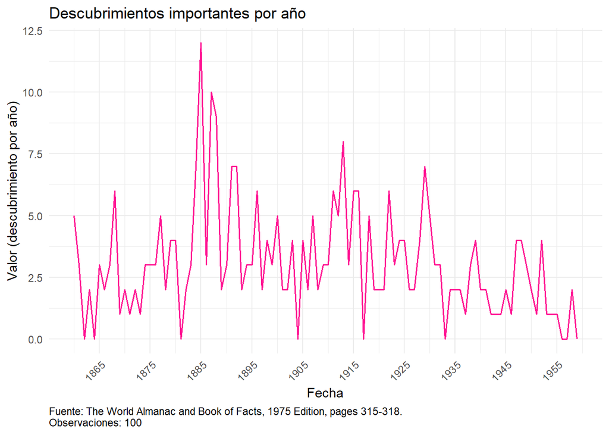

```r
g1 <- graficar_serie(datos, "Descubrimientos importantes por año")
ggsave("figs/e1-serie.png", g1, width = 8, height = 4.5)
g1
```

**Mostrar/ocultar código**

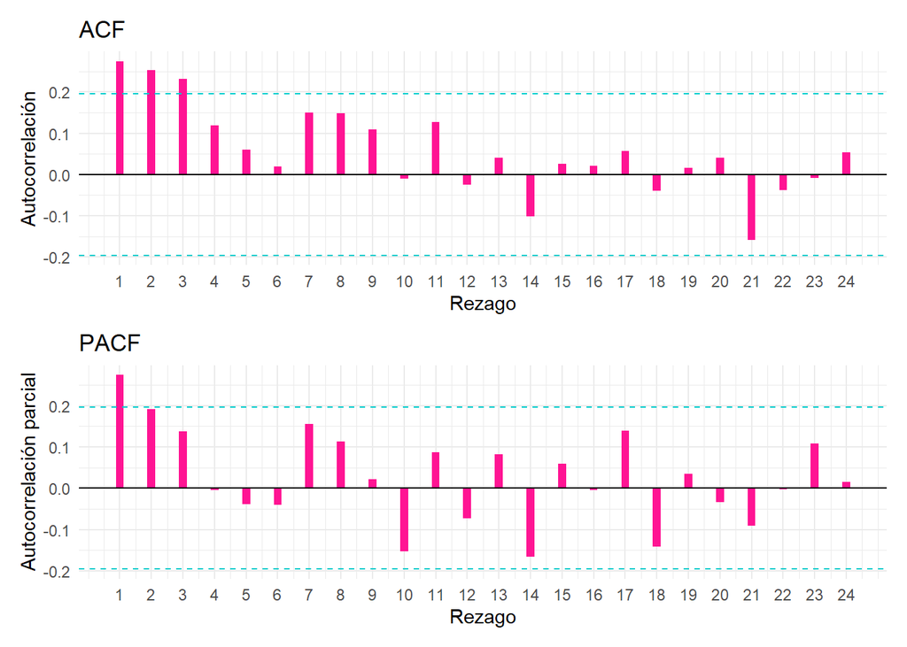

```r
g2 <- correlograma(datos)
ggsave("figs/e1-correlograma.png", g2, width = 8, height = 6)
g2
```

En el gráfico se observa que la serie es estacionaria en media, ya que no presenta cambios de nivel a lo largo del tiempo, lo cual se confirma en el correlograma al ver que los coeficientes de autocorrelación caen rápidamente a cero. Asimismo, la serie no muestra comportamiento estacional, ya que no se aprecian patrones repetitivos en los datos ni picos en rezagos múltiples.

**contraste**

**Mostrar/ocultar código**

```r
m <- min(floor(n / 4), 24)
r <- acf_manual(y, m)
limite <- qnorm(0.975) / sqrt(n)

contraste <- data.frame(rezago = 1:m, rh = r, z = r * sqrt(n), fuera_de_banda = abs(r) > limite)

formatear_tabla(data.frame(banda = limite, r1 = r[1], rezagos_fuera = sum(contraste$fuera_de_banda), esperados_por_azar = 0.05 * m), "Resumen del Contraste")
```

Resumen del Contraste

| banda | r1 | rezagos_fuera | esperados_por_azar |
| --- | --- | --- | --- |
| 0.196 | 0.2741 | 3 | 1.2 |

**Mostrar/ocultar código**

```r
formatear_tabla(contraste[contraste$fuera_de_banda, ], "Rezagos Fuera de Banda")
```

Rezagos Fuera de Banda

| rezago | rh | z | fuera_de_banda |
| --- | --- | --- | --- |
| 1 | 0.2741 | 2.7414 | TRUE |
| 2 | 0.2520 | 2.5205 | TRUE |
| 3 | 0.2310 | 2.3095 | TRUE |

Al analizar la serie discoveries frente a sus primeros 24 rezagos, se observa que únicamente 3 de ellos superan las bandas de significancia estadística. A nivel individual, esto indica que la cantidad de descubrimientos anuales guarda una correlación significativa con la información de periodos específicos pasados (particularmente los primeros rezagos)

**Ljung Box**

**Mostrar/ocultar código**

```r
lb_serie <- ljung_box(r, n, m, 0)
mostrar_prueba_html("Ljung-Box sobre la serie (p = 0)",
               "todas las autocorrelaciones hasta m son cero", "alguna es distinta de cero",
               paste0("chi2 con ", lb_serie$gl, " g.l."), lb_serie)
```

Prueba de Hipótesis: Ljung-Box sobre la serie (p = 0)

| H0 | todas las autocorrelaciones hasta m son cero |
| --- | --- |
| H1 | alguna es distinta de cero |
| Estadístico | 36.254 |
| Distribución | chi2 con 24 g.l. |
| Valor Crítico 5% | 36.415 |
| Valor p | 0.0518 |
| Decisión | no se rechaza H0 al 5% |

**Mostrar/ocultar código**

```r
verificar_ljung_box(y, m)
```

```
Ljung-Box (m = 24 , p = 0 )
   Q propio: 36.25397246 | Q de R: 36.25397246
```

**Partición**

**Mostrar/ocultar código**

```r
h <- min(12, floor(0.2 * n))
n_est <- n - h
y_est <- y[1:n_est]
y_val <- y[(n_est + 1):n]

formatear_tabla(data.frame(h = h, estimacion = n_est, validacion = h), "Partición de la Serie")
```

Partición de la Serie

| h | estimacion | validacion |
| --- | --- | --- |
| 12 | 88 | 12 |

Para la serie discoveries, la partición de los datos se realizó reservando los primeros 88 datos para el conjunto de entrenamiento (estimación del modelo) y los últimos 12 datos para el conjunto de validación, permitiendo evaluar la precisión de las predicciones frente a observaciones reales.

## 1.2 Método

Tal como se evidenció en los análisis gráficos, la serie sugiere ser estacionaria en media y no presenta patrones de tendencia ni estacionalidad. Por lo tanto, se decidió implementar el método de Media Simple. La estimación del nivel medio obtenida a partir del conjunto de entrenamiento fue de 3.307 descubrimientos por año.

**Ajuste**

**Mostrar/ocultar código**

```r
ajuste <- ajustar_media(y_est)
formatear_tabla(data.frame(media = ajuste$parametros$media), "Parámetro Estimado")
```

Parámetro Estimado

| media |
| --- |
| 3.3068 |

**Medidas**

**Mostrar/ocultar código**

```r
p <- 1
pron <- ajuste$pronosticar(h)
pron_ing <- ingenuo(y_est, h)

tabla <- rbind(
  data.frame(caso = "Método, un paso (estimación)", medidas(y_est, ajuste$yhat, y_est)),
  data.frame(caso = "Método, h pasos (validación)", medidas(y_val, pron, y_est)),
  data.frame(caso = "Ingenuo, h pasos (validación)", medidas(y_val, pron_ing, y_est)))

formatear_tabla(tabla, "Comparación de Desempeño")
```

Comparación de Desempeño

| caso | MSE | MAD | MAPE | MASE | n |
| --- | --- | --- | --- | --- | --- |
| Método, un paso (estimación) | 5.4246 | 1.7663 | NA | 0.8306 | 87 |
| Método, h pasos (validación) | 4.8801 | 1.9545 | NA | 0.9192 | 12 |
| Ingenuo, h pasos (validación) | 7.7500 | 2.4167 | NA | 1.1365 | 12 |

Al comparar el método de Media Simple con el método Ingenuo, se observa que la Media Simple obtiene valores menores en todas las métricas de error. Específicamente, registra un MSE de 4.880 en comparación con el 7.750 del método Ingenuo, confirmando un mejor desempeño al cometer en promedio menos errores. Asimismo, el modelo se equivoca en promedio en 1.955 unidades (MAE). Finalmente, un MASE menor a 1 refuerza que la Media Simple supera al pronóstico de referencia.

**Gráficos**

**Mostrar/ocultar código**

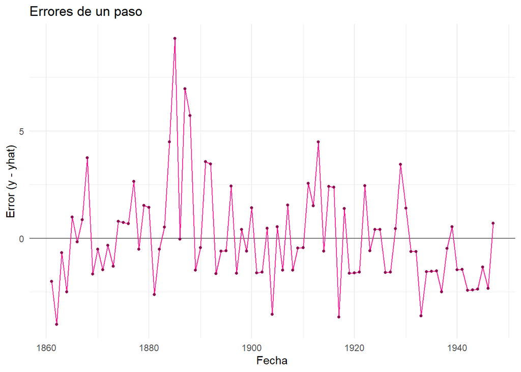

```r
errores <- y_est - ajuste$yhat
ve <- validar_errores(errores, p = p, fechas = datos$fecha[1:n_est])

ggsave("figs/e1-errores.png", ve$grafico_errores, width = 8, height = 3.5)
ggsave("figs/e1-correlograma-errores.png", ve$correlograma, width = 8, height = 6)

ve$grafico_errores
```

**Mostrar/ocultar código**

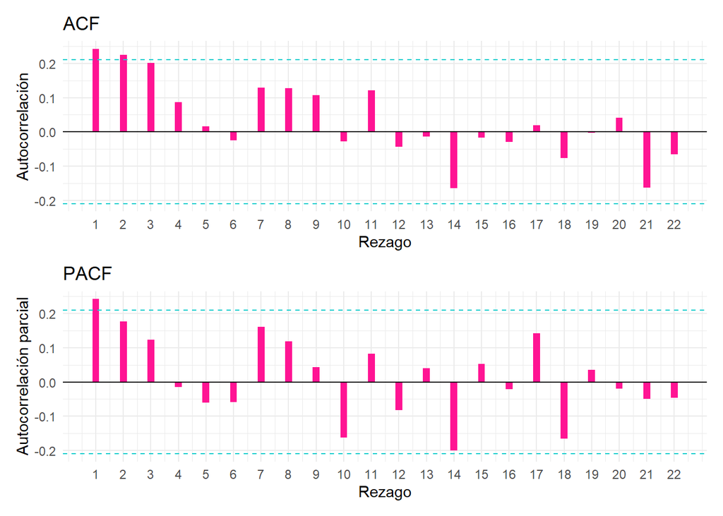

```r
ve$correlograma
```

El correlograma de los residuos confirma que los errores continúan autocorrelacionados, ya que los rezagos 1 y 2 superan las bandas de significancia. Por su parte, la gráfica de los residuos muestra que, aunque estos oscilan alrededor de cero, presentan una dispersión considerable y patrones persistentes, lo que evidencia que el modelo no ha capturado toda la estructura de la serie.

**Pruebas**

**Mostrar/ocultar código**

```r
mostrar_prueba_html("t de media cero", "E[e] = 0", "E[e] distinto de 0", paste0("t con ", ve$prueba_t$gl, " g.l."), ve$prueba_t)
```

Prueba de Hipótesis: t de media cero

| H0 | E[e] = 0 |
| --- | --- |
| H1 | E[e] distinto de 0 |
| Estadístico | 0.19538 |
| Distribución | t con 87 g.l. |
| Valor Crítico 5% | 1.9876 |
| Valor p | 0.846 |
| Decisión | no se rechaza H0 al 5% |

**Mostrar/ocultar código**

```r
mostrar_prueba_html("Ljung-Box sobre errores", "no hay autocorrelación hasta m", "hay autocorrelación", paste0("chi2 con ", ve$ljung_box$gl, " g.l."), ve$ljung_box)
```

Prueba de Hipótesis: Ljung-Box sobre errores

| H0 | no hay autocorrelación hasta m |
| --- | --- |
| H1 | hay autocorrelación |
| Estadístico | 28.434 |
| Distribución | chi2 con 21 g.l. |
| Valor Crítico 5% | 32.671 |
| Valor p | 0.128 |
| Decisión | no se rechaza H0 al 5% |

**Mostrar/ocultar código**

```r
mostrar_prueba_html("Jarque-Bera", "los errores son normales", "los errores no son normales", "chi2 con 2 g.l.", ve$jarque_bera, nota = if (ve$n < 20) paste("solo hay", ve$n, "errores (< 20)"))
```

Prueba de Hipótesis: Jarque-Bera

| H0 | los errores son normales |
| --- | --- |
| H1 | los errores no son normales |
| Estadístico | 41.267 |
| Distribución | chi2 con 2 g.l. |
| Valor Crítico 5% | 5.9915 |
| Valor p | 1.09e-09 |
| Decisión | se rechaza H0 al 5% |

**Mostrar/ocultar código**

```r
mostrar_prueba_html("Durbin-Watson", "no hay autocorrelación de primer orden", "hay autocorrelacion de primer orden", "d entre 0 y 4", ve$durbin_watson)
```

Prueba de Hipótesis: Durbin-Watson

| H0 | no hay autocorrelación de primer orden |
| --- | --- |
| H1 | hay autocorrelacion de primer orden |
| Estadístico | 1.5043 |
| Distribución | d entre 0 y 4 |
| Valor Crítico 5% | no aplica |
| Valor p | no aplica |
| Decisión | se compara con las cotas dL y dU de la tabla |

**Prueba t de media cero:** Con un valor p = 0.846, no se rechaza la hipótesis nula, lo que indica que no existe evidencia estadística para sugerir sesgo en las predicciones.

**Prueba de Ljung-Box:** Se obtuvo un valor p = 0.128, por lo que no se rechaza H0. Esto sugiere que, de forma conjunta en los primeros rezagos, no hay autocorrelación global significativa.

**Prueba de Jarque-Bera:** Al obtener un valor p inferior a cualquier nivel de significancia , se rechaza H0, lo que confirma que los residuos no siguen una distribución normal.

**Prueba de Durbin-Watson:** El estadístico se ubicó en 1.5043. Al estar por debajo de 2, sugiere la presencia de cierta autocorrelación positiva de primer orden en los errores, lo cual coincide con los picos observados en los primeros rezagos del correlograma.

**Gráfico Final**

**Mostrar/ocultar código**

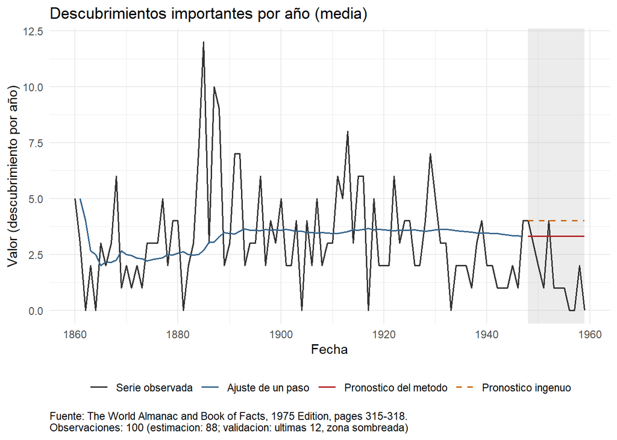

```r
g_final <- grafico_pronostico(datos, n_est, ajuste$yhat, pron, "Descubrimientos importantes por año (media)", ingenuo = pron_ing)
ggsave("figs/e1-final.png", g_final, width = 8, height = 4.5)
g_final
```

**Conclusión:** Se ajustó un modelo de Media Simple estimando un nivel medio de 3.307 descubrimientos anuales a partir de un conjunto de entrenamiento de 88 observaciones y validado en 12 periodos. Frente al método ingenuo, que obtuvo un MSE de 7.750, el modelo ajustado redujo el MSE a 4.880, con un MAE de 1.955 y un MASE inferior a 1. La validación de errores mostró ausencia de sesgo (p=0.846 en la prueba t) y de autocorrelación conjunta (p=0.128 en Ljung-Box), aunque los residuos no fueron normales (Jarque-Bera con p<0.05) y mostraron leve autocorrelación de primer orden con un estadístico Durbin-Watson de 1.5043

**Recomendación:** Este pronóstico le sirve a personas que organizan presupuestos o planes científicos y solo necesitan una idea general de cuántos avances se logran por año a largo plazo, sin importar los altibajos de cada año. Es razonable usarlo para planear en periodos de corto a mediano plazo, hasta un máximo de 12 años. Su gran limitación es que es un método muy rígido que no se da cuenta si los descubrimientos están subiendo o bajando recientemente, lo que deja un fallo promedio de 1.955 descubrimientos por año respecto a lo que ocurre en la realidad.

# 2 Ejemplo 2: Media Móvil

La serie analiza el número de grandes descubrimientos científicos por año entre 1860 y 1959, registrada bajo el nombre `discoveries` en R. Cuenta con un total de 100 observaciones anuales (frecuencia 1) extraídas de The World Almanac and Book of Facts (edición de 1975).

**Mostrar/ocultar código**

```r
# 1. Descripción
fuente <- fuente_help("discoveries")
datos <- leer_serie(discoveries, fuente, "descubrimientos por año")
n <- nrow(datos)
y <- datos$y

stopifnot(n == length(discoveries), all(y == as.numeric(discoveries)))

df_desc <- data.frame(
  Propiedad = c("Nombre en R", "Fuente", "Unidad", "Frecuencia", "Rango Fechas", "Observaciones"),
  Detalle = c("discoveries", fuente, "descubrimientos por año",
              attr(datos, "frecuencia"),
              paste(format(min(datos$fecha)), "a", format(max(datos$fecha))),
              as.character(n))
)
formatear_tabla(df_desc, "1. DESCRIPCIÓN - Ejemplo 2")
```

1. DESCRIPCIÓN - Ejemplo 2

| Propiedad | Detalle |
| --- | --- |
| Nombre en R | discoveries |
| Fuente | The World Almanac and Book of Facts, 1975 Edition, pages 315-318. |
| Unidad | descubrimientos por año |
| Frecuencia | 1 |
| Rango Fechas | 1860-01-01 a 1959-01-01 |
| Observaciones | 100 |

## 2.1 Patrón de la Serie

**Gráficos**

**Mostrar/ocultar código**

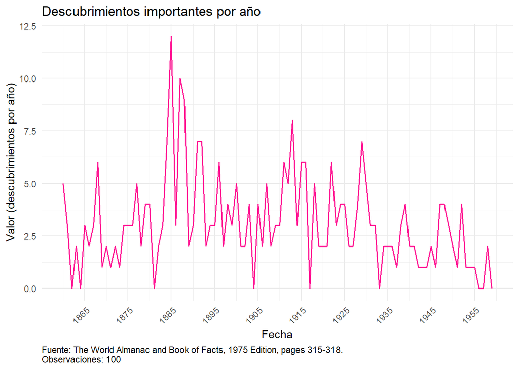

```r
# 2. Patrón de la Serie
g_serie <- graficar_serie(datos, "Descubrimientos importantes por año")
ggsave("figs/e2-serie.png", g_serie, width = 8, height = 4.5)
g_serie
```

**Mostrar/ocultar código**

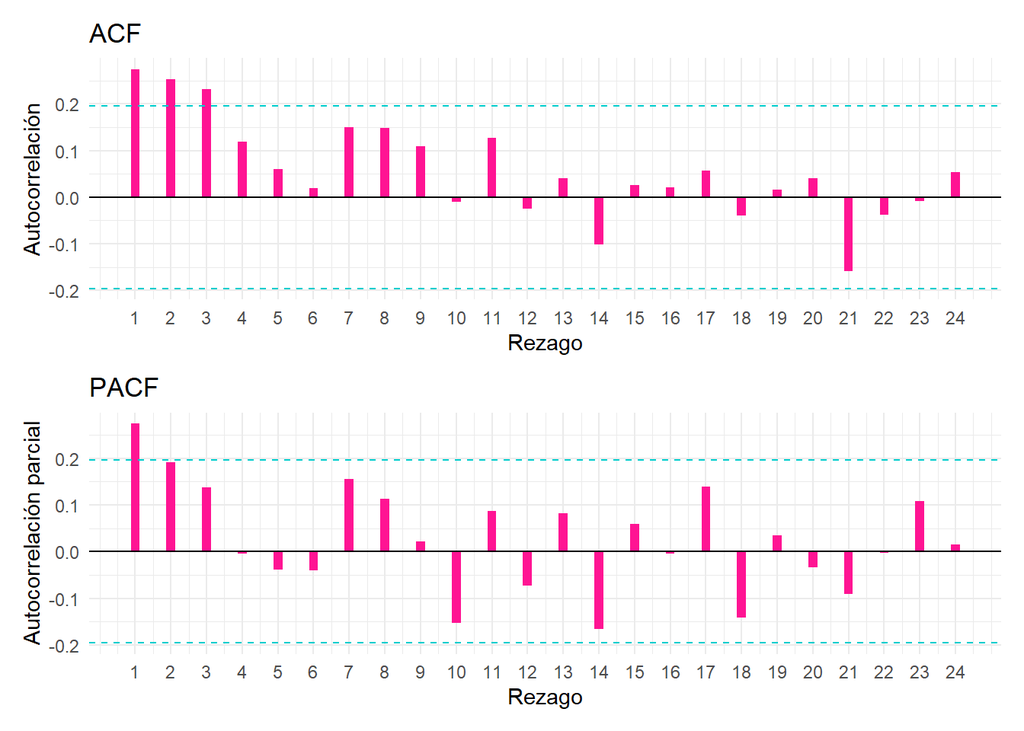

```r
g_corr <- correlograma(datos)
ggsave("figs/e2-correlograma.png", g_corr, width = 8, height = 6)
g_corr
```

En el gráfico se observa que la serie es estacionaria en media, ya que no presenta cambios de nivel a lo largo del tiempo, lo cual se confirma en el correlograma al ver que los coeficientes de autocorrelación caen rápidamente a cero. Asimismo, la serie no muestra comportamiento estacional, ya que no se aprecian patrones repetitivos en los datos ni picos en rezagos múltiples.

**Contraste**

**Mostrar/ocultar código**

```r
m <- min(floor(n / 4), 24)
r <- acf_manual(y, m)
limite <- qnorm(0.975) / sqrt(n)

contraste <- data.frame(rezago = 1:m, rh = r, z = r * sqrt(n), fuera_de_banda = abs(r) > limite)

formatear_tabla(data.frame(banda = limite, r1 = r[1], rezagos_fuera = sum(contraste$fuera_de_banda), esperados_por_azar = 0.05 * m), "Resumen del Contraste")
```

Resumen del Contraste

| banda | r1 | rezagos_fuera | esperados_por_azar |
| --- | --- | --- | --- |
| 0.196 | 0.2741 | 3 | 1.2 |

**Mostrar/ocultar código**

```r
formatear_tabla(contraste[contraste$fuera_de_banda, ], "Rezagos Fuera de Banda")
```

Rezagos Fuera de Banda

| rezago | rh | z | fuera_de_banda |
| --- | --- | --- | --- |
| 1 | 0.2741 | 2.7414 | TRUE |
| 2 | 0.2520 | 2.5205 | TRUE |
| 3 | 0.2310 | 2.3095 | TRUE |

Al analizar la serie discoveries frente a sus primeros 24 rezagos, se observa que únicamente 3 de ellos superan las bandas de significancia estadística. A nivel individual, esto indica que la cantidad de descubrimientos anuales guarda una correlación significativa con la información de periodos específicos pasados (particularmente los primeros rezagos)

**Ljung Box**

**Mostrar/ocultar código**

```r
lb_serie <- ljung_box(r, n, m, 0)
mostrar_prueba_html("Ljung-Box sobre la serie (p = 0)",
               "todas las autocorrelaciones hasta m son cero", "alguna es distinta de cero",
               paste0("chi2 con ", lb_serie$gl, " g.l."), lb_serie)
```

Prueba de Hipótesis: Ljung-Box sobre la serie (p = 0)

| H0 | todas las autocorrelaciones hasta m son cero |
| --- | --- |
| H1 | alguna es distinta de cero |
| Estadístico | 36.254 |
| Distribución | chi2 con 24 g.l. |
| Valor Crítico 5% | 36.415 |
| Valor p | 0.0518 |
| Decisión | no se rechaza H0 al 5% |

**Mostrar/ocultar código**

```r
verificar_ljung_box(y, m)
```

```
Ljung-Box (m = 24 , p = 0 )
   Q propio: 36.25397246 | Q de R: 36.25397246
```

**Partición**

**Mostrar/ocultar código**

```r
h <- min(12, floor(0.2 * n))
n_est <- n - h
y_est <- y[1:n_est]
y_val <- y[(n_est + 1):n]

formatear_tabla(data.frame(h = h, estimacion = n_est, validacion = h), "Partición de la Serie")
```

Partición de la Serie

| h | estimacion | validacion |
| --- | --- | --- |
| 12 | 88 | 12 |

Para la serie discoveries, la partición de los datos se realizó reservando los primeros 88 datos para el conjunto de entrenamiento (estimación del modelo) y los últimos 12 datos para el conjunto de validación, permitiendo evaluar la precisión de las predicciones frente a observaciones reales.

## 2.2 Método

Tal como se evidenció en los análisis gráficos, la serie no presenta una tendencia ni un patrón de estacionalidad definidos, por lo que constituye una buena candidata para ser modelada mediante una Media Móvil.

**Optimo**

**Mostrar/ocultar código**

```r
# 3. Ajuste (mm)
opt <- optimizar(y_est, "mm")
formatear_tabla(cbind(opt$optimo, en_borde = opt$en_borde), "4. AJUSTE (mm) - Optimización")
```

4. AJUSTE (mm) - Optimización

| k | mse | en_borde |
| --- | --- | --- |
| 9 | 5.1567 | FALSE |

**Mostrar/ocultar código**

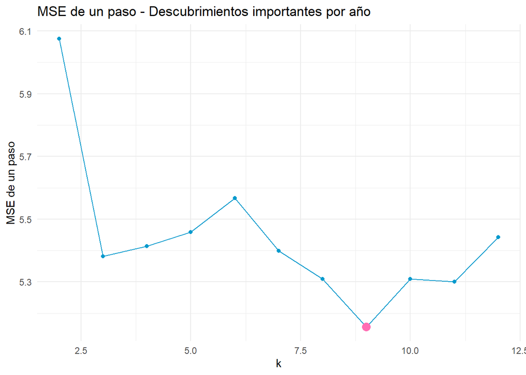

```r
g_opt <- grafico_mse(opt, "MSE de un paso - Descubrimientos importantes por año")
ggsave("figs/e2-optimizacion.png", g_opt, width = 7, height = 5)
g_opt
```

**Mostrar/ocultar código**

```r
interpretar_borde(opt)

ajuste <- ajustar_mm(y_est, opt$optimo$k)
```

El proceso de optimización indicó que el tamaño adecuado para la Media Móvil es de 9 periodos, lo que significa que el pronóstico se calcula utilizando únicamente el promedio de las últimas 9 observaciones. Este parámetro ofrece el mejor ajuste al registrar el MSE bajo 5.15 y resulta válido al no encontrarse en los límites del rango evaluado (que iba de 2 a 12), es decir, no fue necesario ampliar la búsqueda para encontrar un mejor valor. En el gráfico se ve cómo con ventanas muy cortas, como 2 años, el error es mucho más alto, porque el promedio sigue muy de cerca cada dato suelto en vez de suavizarlo; a medida que la ventana crece, el error baja hasta llegar a su punto más bajo en 9, y luego vuelve a subir un poco. Esto muestra que 9 años es el punto justo: ni tan corto que reaccione de más a los datos, ni tan largo que se demore en captar los cambios reales del nivel de la serie.

**Medidas**

**Mostrar/ocultar código**

```r
p <- 1

pron <- ajuste$pronosticar(h)
pron_ing <- ingenuo(y_est, h)

tabla <- rbind(
  data.frame(caso = "Método, un paso (estimación)", medidas(y_est, ajuste$yhat, y_est)),
  data.frame(caso = "Método, h pasos (validación)", medidas(y_val, pron, y_est)),
  data.frame(caso = "Ingenuo, h pasos (validación)", medidas(y_val, pron_ing, y_est)))
formatear_tabla(tabla, "Medidas y Comparación")
```

Medidas y Comparación

| caso | MSE | MAD | MAPE | MASE | n |
| --- | --- | --- | --- | --- | --- |
| Método, un paso (estimación) | 5.1567 | 1.7103 | NA | 0.8043 | 79 |
| Método, h pasos (validación) | 2.0833 | 1.2500 | NA | 0.5878 | 12 |
| Ingenuo, h pasos (validación) | 7.7500 | 2.4167 | NA | 1.1365 | 12 |

Al comparar la Media Móvil con el método Ingenuo en el periodo de validación, se observa que la Media Móvil obtiene valores menores en todas las métricas de error. Registra un MSE de 2.083 frente al 7.750 del pronóstico Ingenuo, confirmando un mejor desempeño al cometer errores de menor magnitud. Asimismo, la Media Móvil se equivoca en promedio en 1.250 unidades (MAE), prácticamente la mitad de lo reportado por el método Ingenuo. Finalmente, al obtener un MASE menor a 1, se reafirma que el modelo supera de forma clara al pronóstico de referencia.

**Validación Errores**

**Mostrar/ocultar código**

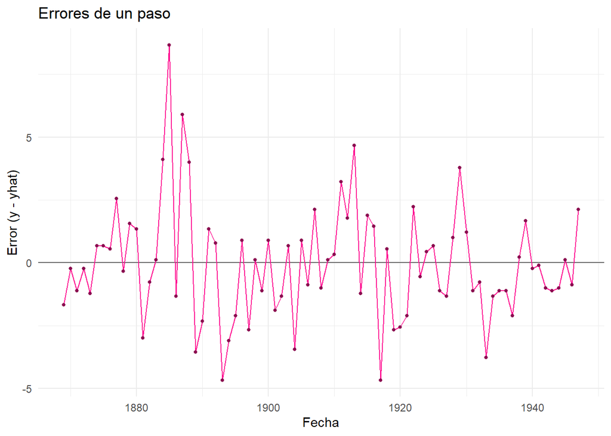

```r
# 4. Errores de un paso
errores <- y_est - ajuste$yhat
ve <- validar_errores(errores, p = p, fechas = datos$fecha[1:n_est])

ggsave("figs/e2-errores.png", ve$grafico_errores, width = 8, height = 3.5)
ggsave("figs/e2-correlograma-errores.png", ve$correlograma, width = 8, height = 6)

ve$grafico_errores
```

**Mostrar/ocultar código**

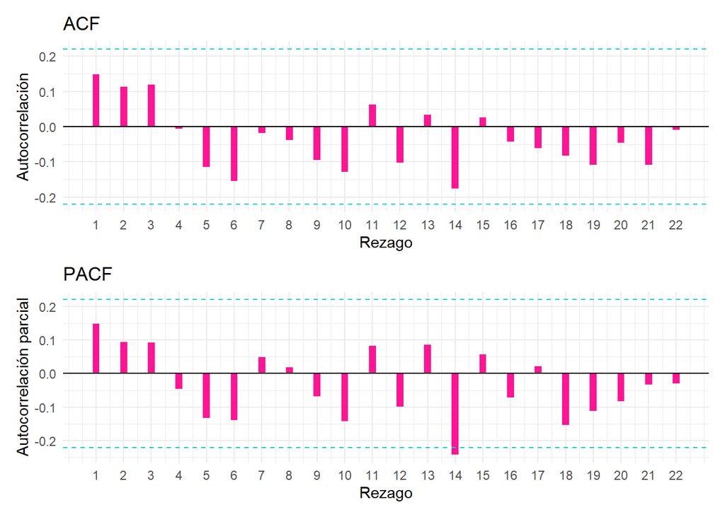

```r
ve$correlograma
```

**Pruebas**

**Mostrar/ocultar código**

```r
mostrar_prueba_html("t de media cero", "E[e] = 0", "E[e] distinto de 0", paste0("t con ", ve$prueba_t$gl, " g.l."), ve$prueba_t)
```

Prueba de Hipótesis: t de media cero

| H0 | E[e] = 0 |
| --- | --- |
| H1 | E[e] distinto de 0 |
| Estadístico | -0.24256 |
| Distribución | t con 87 g.l. |
| Valor Crítico 5% | 1.9876 |
| Valor p | 0.809 |
| Decisión | no se rechaza H0 al 5% |

**Mostrar/ocultar código**

```r
mostrar_prueba_html("Ljung-Box sobre los errores", "no hay autocorrelación hasta m", "hay autocorrelación", paste0("chi2 con ", ve$ljung_box$gl, " g.l. (m - p)"), ve$ljung_box)
```

Prueba de Hipótesis: Ljung-Box sobre los errores

| H0 | no hay autocorrelación hasta m |
| --- | --- |
| H1 | hay autocorrelación |
| Estadístico | 20.297 |
| Distribución | chi2 con 21 g.l. (m - p) |
| Valor Crítico 5% | 32.671 |
| Valor p | 0.503 |
| Decisión | no se rechaza H0 al 5% |

**Mostrar/ocultar código**

```r
mostrar_prueba_html("Jarque-Bera", "los errores son normales", "los errores no son normales", "chi2 con 2 g.l. (asintótica)", ve$jarque_bera, nota = if (ve$n < 20) paste("solo hay", ve$n, "errores (< 20): la decisión es poco fiable"))
```

Prueba de Hipótesis: Jarque-Bera

| H0 | los errores son normales |
| --- | --- |
| H1 | los errores no son normales |
| Estadístico | 22.548 |
| Distribución | chi2 con 2 g.l. (asintótica) |
| Valor Crítico 5% | 5.9915 |
| Valor p | 1.27e-05 |
| Decisión | se rechaza H0 al 5% |

**Mostrar/ocultar código**

```r
mostrar_prueba_html("Durbin-Watson", "no hay autocorrelación de primer orden", "hay autocorrelación de primer orden", "d entre 0 y 4", ve$durbin_watson)
```

Prueba de Hipótesis: Durbin-Watson

| H0 | no hay autocorrelación de primer orden |
| --- | --- |
| H1 | hay autocorrelación de primer orden |
| Estadístico | 1.6839 |
| Distribución | d entre 0 y 4 |
| Valor Crítico 5% | no aplica |
| Valor p | no aplica |
| Decisión | se compara con las cotas dL y dU de la tabla |

**t de media cero:** Con un valor p de 0.809, no se rechaza la hipótesis nula, lo que indica que no existe evidencia estadística para sugerir sesgo en las predicciones.

**Ljung-Box:** Se obtuvo un valor p de 0.503, por lo que no se rechaza la hipótesis nula. Esto confirma la ausencia de autocorrelación conjunta en los errores, respaldando la presencia de ruido blanco en coherencia con lo observado en el correlograma.

**Jarque-Bera:** Al ser el valor p inferior a cualquier nivel de significancia alfa, se rechaza la hipótesis nula, lo que demuestra que los residuos no siguen una distribución normal.

**Durbin-Watson:** El estadístico se ubicó en 1.6839. Al estar cercano a 2, confirma que el modelo de Media Móvil eliminó efectivamente la autocorrelación de primer orden en los errores.

### 2.2.1 Gráfico Final

**Mostrar/ocultar código**

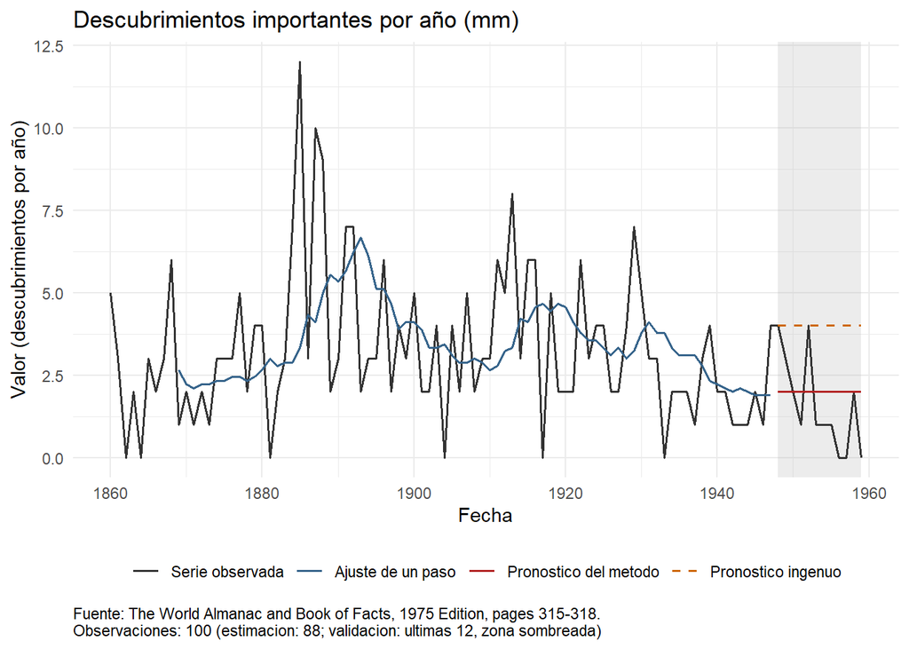

```r
g_final <- grafico_pronostico(datos, n_est, ajuste$yhat, pron, "Descubrimientos importantes por año (mm)", ingenuo = pron_ing)
ggsave("figs/e2-final.png", g_final, width = 8, height = 4.5)
g_final
```

Al comparar los dos métodos aplicados a esta serie, se observa que la Media Móvil captura de forma más precisa su comportamiento, ya que se adapta a la información reciente, a diferencia de la Media Simple que aplica un ajuste rígido basado en toda la historia. Dado que la serie registraba una tendencia decreciente en el tramo final, la Media Móvil logró detectar esta caída y generar un pronóstico superior.

**Conclusión:** Se ajustó un modelo de Media Móvil con un tamaño de ventana óptimo de k=9 periodos, evaluado en una partición de 88 datos de entrenamiento y 12 de validación. Frente al método ingenuo, el cual registró un MSE de 7.750, la Media Móvil mejoró la precisión produciendo un MSE de 2.083, un MAE de 1.250 y un MASE menor a 1. La validación de errores confirmó ausencia de sesgo (p=0.809 en la prueba t), comportamiento de ruido blanco sin autocorrelación conjunta (p=0.503 en Ljung-Box) y un estadístico Durbin-Watson de 1.6839, aunque persiste la no normalidad en los residuos (p<0.05 en Jarque-Bera).

**Recomendaciones:** Esta proyección le sirve a los directores de universidades o centros de investigación que quieren predecir los resultados de los próximos años basándose solo en lo que ha pasado últimamente, suavizando los brincos raros de un solo año. Lo más sensato es usarlo para mirar de 1 a 3 años hacia el futuro antes de volver a actualizar las cuentas. El techo o límite del método es que, cuando la cifra real cae o sube de golpe, se tarda en reaccionar, generando un margen de error promedio de 1.250 descubrimientos al año.

# 3 Ejemplo 3: Suavizamiento Exponencial Simple (SES)

La serie registra el flujo anual del río Nilo entre 1871 y 1970, almacenada bajo el nombre `Nile` en R. Contiene un total de 100 observaciones anuales (frecuencia 1) expresadas en cientos de millones de metros cúbicos. Los datos provienen del trabajo de Durbin y Koopman (2001) sobre análisis de series de tiempo.

**Mostrar/ocultar código**

```r
# 1. Descripción
fuente <- fuente_help("Nile")
datos <- leer_serie(Nile, fuente, "10^8 m^3")
n <- nrow(datos)
y <- datos$y

stopifnot(n == length(Nile), all(y == as.numeric(Nile)))

df_desc <- data.frame(
  Propiedad = c("Nombre en R", "Fuente", "Unidad", "Frecuencia", "Rango Fechas", "Observaciones"),
  Detalle = c("Nile", fuente, "10^8 m^3",
              attr(datos, "frecuencia"),
              paste(format(min(datos$fecha)), "a", format(max(datos$fecha))),
              as.character(n))
)
formatear_tabla(df_desc, "1. DESCRIPCIÓN - Ejemplo 3")
```

1. DESCRIPCIÓN - Ejemplo 3

| Propiedad | Detalle |
| --- | --- |
| Nombre en R | Nile |
| Fuente | Durbin, J. and Koopman, S. J. (2001). Time Series Analysis by State Space Methods. Oxford University Press. |
| Unidad | 10^8 m^3 |
| Frecuencia | 1 |
| Rango Fechas | 1871-01-01 a 1970-01-01 |
| Observaciones | 100 |

## 3.1 Patrón de la Serie

**Gráficos**

**Mostrar/ocultar código**

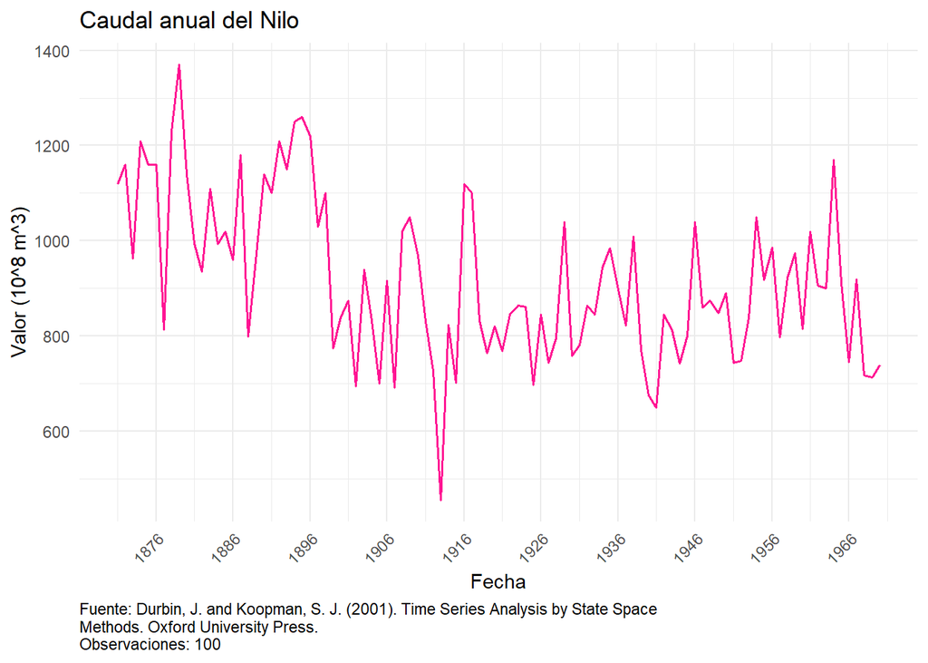

```r
# 2. Patrón de la Serie
g_serie <- graficar_serie(datos, "Caudal anual del Nilo")
ggsave("figs/e3-serie.png", g_serie, width = 8, height = 4.5)
g_serie
```

**Mostrar/ocultar código**

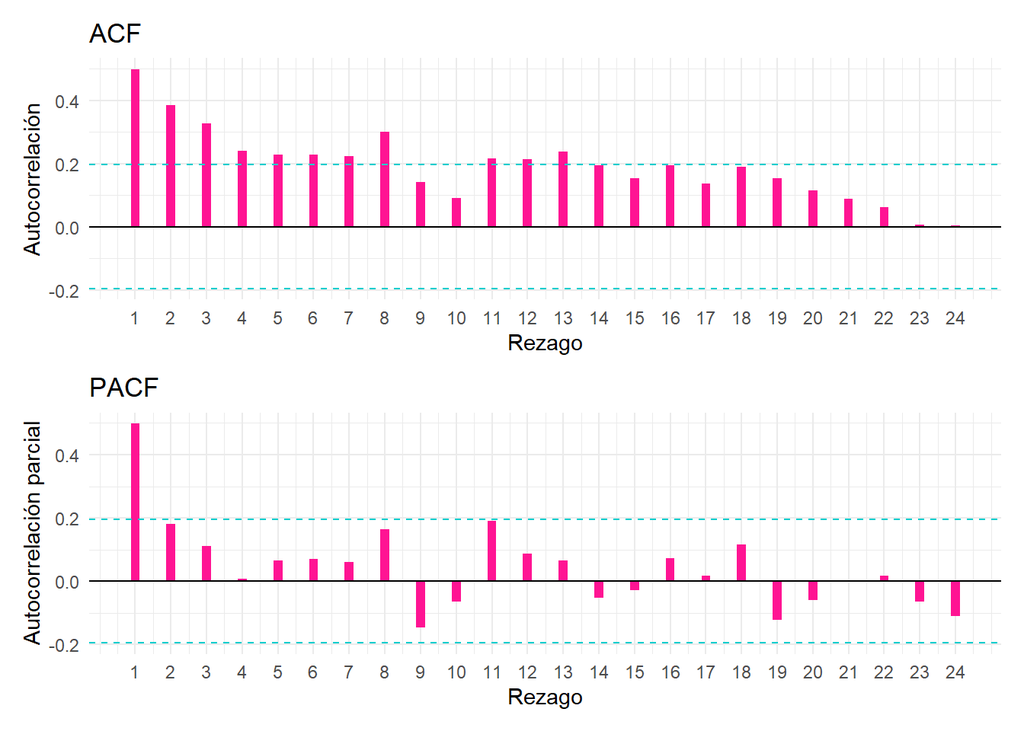

```r
g_corr <- correlograma(datos)
ggsave("figs/e3-correlograma.png", g_corr, width = 8, height = 6)
g_corr
```

La serie presenta un cambio estructural en su comportamiento. Este cambio abrupto de nivel a finales del siglo XIX coincidió con la construcción de la primera presa de Asuán (1898–1902) en Egipto, lo que alteró de forma permanente la regulación y medición del flujo medio del río. Por su parte, el correlograma muestra la ausencia de patrones estacionales o de rezagos múltiples significativos.

**Contraste**

**Mostrar/ocultar código**

```r
m <- min(floor(n / 4), 24)
r <- acf_manual(y, m)
limite <- qnorm(0.975) / sqrt(n)

contraste <- data.frame(rezago = 1:m, rh = r, z = r * sqrt(n), fuera_de_banda = abs(r) > limite)

formatear_tabla(data.frame(banda = limite, r1 = r[1], rezagos_fuera = sum(contraste$fuera_de_banda), esperados_por_azar = 0.05 * m), "Resumen del Contraste")
```

Resumen del Contraste

| banda | r1 | rezagos_fuera | esperados_por_azar |
| --- | --- | --- | --- |
| 0.196 | 0.4984 | 11 | 1.2 |

**Mostrar/ocultar código**

```r
formatear_tabla(contraste[contraste$fuera_de_banda, ], "Rezagos Fuera de Banda")
```

Rezagos Fuera de Banda

|  | rezago | rh | z | fuera_de_banda |
| --- | --- | --- | --- | --- |
| 1 | 1 | 0.4984 | 4.9841 | TRUE |
| 2 | 2 | 0.3846 | 3.8458 | TRUE |
| 3 | 3 | 0.3279 | 3.2786 | TRUE |
| 4 | 4 | 0.2392 | 2.3919 | TRUE |
| 5 | 5 | 0.2284 | 2.2842 | TRUE |
| 6 | 6 | 0.2273 | 2.2730 | TRUE |
| 7 | 7 | 0.2220 | 2.2205 | TRUE |
| 8 | 8 | 0.3000 | 2.9996 | TRUE |
| 11 | 11 | 0.2155 | 2.1548 | TRUE |
| 12 | 12 | 0.2129 | 2.1292 | TRUE |
| 13 | 13 | 0.2370 | 2.3698 | TRUE |

Al analizar los primeros 24 rezagos en el correlograma, se observa que 11 de ellos superan los límites de significancia. Esto confirma la presencia de una fuerte autocorrelación persistente a lo largo de los años, un comportamiento característico en series con cambios de nivel.

**Ljung Box**

**Mostrar/ocultar código**

```r
lb_serie <- ljung_box(r, n, m, 0)
mostrar_prueba_html("Ljung-Box sobre la serie (p = 0)",
               "todas las autocorrelaciones hasta m son cero", "alguna es distinta de cero",
               paste0("chi2 con ", lb_serie$gl, " g.l."), lb_serie)
```

Prueba de Hipótesis: Ljung-Box sobre la serie (p = 0)

| H0 | todas las autocorrelaciones hasta m son cero |
| --- | --- |
| H1 | alguna es distinta de cero |
| Estadístico | 130.18 |
| Distribución | chi2 con 24 g.l. |
| Valor Crítico 5% | 36.415 |
| Valor p | 1.44e-16 |
| Decisión | se rechaza H0 al 5% |

**Mostrar/ocultar código**

```r
verificar_ljung_box(y, m)
```

```
Ljung-Box (m = 24 , p = 0 )
   Q propio: 130.1799575 | Q de R: 130.1799575
```

Al obtener un valor p inferior a cualquier nivel de significancia alfa, se rechaza la hipótesis nula. Esto confirma la presencia de autocorrelación conjunta en la serie histórica, lo que respalda lo observado previamente en el correlograma.

**Partición**

**Mostrar/ocultar código**

```r
h <- min(12, floor(0.2 * n))
n_est <- n - h
y_est <- y[1:n_est]
y_val <- y[(n_est + 1):n]

formatear_tabla(data.frame(h = h, estimacion = n_est, validacion = h), "Partición de la Serie")
```

Partición de la Serie

| h | estimacion | validacion |
| --- | --- | --- |
| 12 | 88 | 12 |

La serie se dividió en un conjunto de entrenamiento con 88 observaciones para la estimación del modelo y un conjunto de validación con los 12 datos restantes para la evaluación de las predicciones.

## 3.2 Método

A pesar de la autocorrelación presente en la serie, el Suavizamiento Exponencial Simple (SES) resulta viable para el periodo de validación. Esto se debe a que el cambio estructural ocurrió en los primeros años de la serie y el modelo asigna un mayor peso a las observaciones más recientes, minimizando el impacto de dicho quiebre en los pronósticos futuros.

**Optimización**

**Mostrar/ocultar código**

```r
# 3. Ajuste (ses)
opt <- optimizar(y_est, "ses")
formatear_tabla(cbind(opt$optimo, en_borde = opt$en_borde), "4. AJUSTE (ses) - Optimización")
```

4. AJUSTE (ses) - Optimización

| alpha | mse | en_borde |
| --- | --- | --- |
| 0.24 | 20937.26 | FALSE |

**Mostrar/ocultar código**

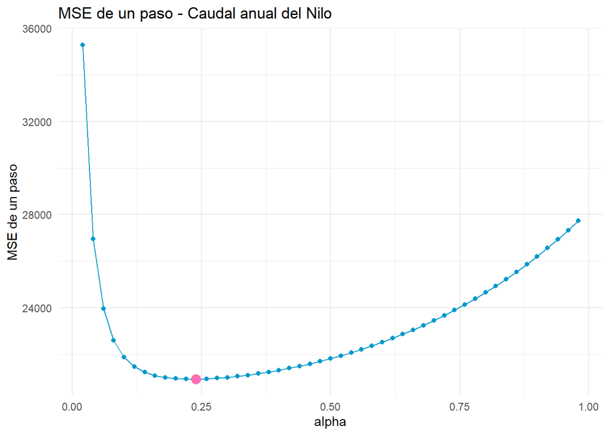

```r
g_opt <- grafico_mse(opt, "MSE de un paso - Caudal anual del Nilo")
ggsave("figs/e3-optimizacion.png", g_opt, width = 7, height = 5)
g_opt
```

El proceso de optimización determinó un valor de alfa de 0.24, lo que refleja un ajuste equilibrado al no reaccionar de manera desmedida ante las fluctuaciones de un año a otro. Asimismo, al comprobar que el error cuadrático medio no se encuentra en los límites del rango de búsqueda, se confirma que la estimación del parámetro no es un resultado forzado. En el gráfico se ve una curva en forma de “U”: con valores de alfa muy bajos (cerca de 0) el pronóstico casi no reacciona a los datos nuevos y el error es alto; con valores muy altos (cerca de 1) el método le da demasiado peso al último dato, ignorando el resto de la historia, y el error también sube. El punto más bajo de esa curva, marcado en rosado, está justo en 0.24, lejos de los dos extremos, lo que indica que ni un ajuste muy lento ni uno muy brusco son los adecuados para seguir el nivel cambiante del caudal del río.

**Medidas**

**Mostrar/ocultar código**

```r
interpretar_borde(opt)

ajuste <- ajustar_ses(y_est, opt$optimo$alpha)
p <- 1

pron <- ajuste$pronosticar(h)
pron_ing <- ingenuo(y_est, h)

tabla <- rbind(
  data.frame(caso = "Método, un paso (estimación)", medidas(y_est, ajuste$yhat, y_est)),
  data.frame(caso = "Método, h pasos (validación)", medidas(y_val, pron, y_est)),
  data.frame(caso = "Ingenuo, h pasos (validación)", medidas(y_val, pron_ing, y_est)))
formatear_tabla(tabla, "Medidas y Comparación")
```

Medidas y Comparación

| caso | MSE | MAD | MAPE | MASE | n |
| --- | --- | --- | --- | --- | --- |
| Método, un paso (estimación) | 20937.26 | 113.6056 | 13.0893 | 0.8551 | 87 |
| Método, h pasos (validación) | 17864.46 | 107.1168 | 12.6004 | 0.8062 | 12 |
| Ingenuo, h pasos (validación) | 19685.00 | 111.0000 | 13.4537 | 0.8355 | 12 |

El método de Suavizamiento Exponencial Simple obtiene un mejor desempeño que el método ingenuo en todas las métricas evaluadas. En el caso del MSE, el método SES registra un valor de 17864 frente a 19685 del pronóstico ingenuo, lo que indica que comete errores de menor magnitud en promedio. Asimismo, el error absoluto promedio (MAE) es de 107 unidades para el SES frente a 111 del ingenuo. En términos porcentuales (MAPE), el método escogido se aleja en promedio un 12.6% de los valores reales, mientras que el ingenuo lo hace en un 13.5%. Finalmente, al obtener un MASE menor a 1, se ratifica que la propuesta supera con claridad al pronóstico de referencia.

**Validación Errores**

**Mostrar/ocultar código**

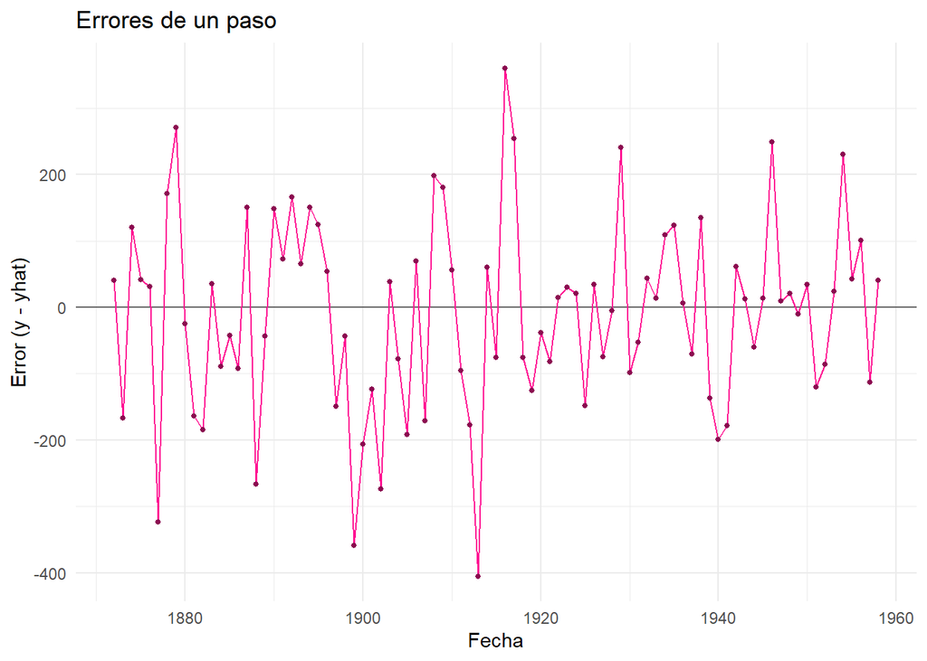

```r
# 4. Errores de un paso
errores <- y_est - ajuste$yhat
ve <- validar_errores(errores, p = p, fechas = datos$fecha[1:n_est])

ggsave("figs/e3-errores.png", ve$grafico_errores, width = 8, height = 3.5)
ggsave("figs/e3-correlograma-errores.png", ve$correlograma, width = 8, height = 6)

ve$grafico_errores
```

**Mostrar/ocultar código**

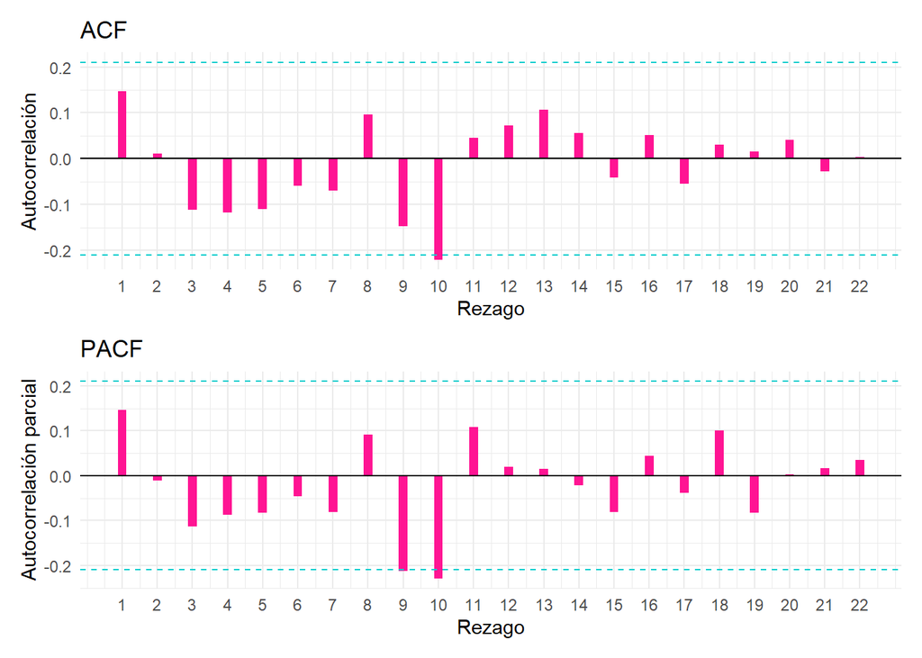

```r
ve$correlograma
```

En el correlograma se observa que la totalidad de los rezagos se mantiene dentro de las bandas de significancia, a excepción de uno solo que las sobrepasa levemente. Esto sugiere la ausencia de autocorrelación en los errores, respaldando su comportamiento como ruido blanco. Asimismo, la gráfica de residuos muestra que estos oscilan alrededor de cero y se distribuyen de forma aleatoria, aunque con la presencia de algunos valores atípicos pronunciados.

**Pruebas**

**Mostrar/ocultar código**

```r
mostrar_prueba_html("t de media cero", "E[e] = 0", "E[e] distinto de 0", paste0("t con ", ve$prueba_t$gl, " g.l."), ve$prueba_t)
```

Prueba de Hipótesis: t de media cero

| H0 | E[e] = 0 |
| --- | --- |
| H1 | E[e] distinto de 0 |
| Estadístico | -0.70492 |
| Distribución | t con 87 g.l. |
| Valor Crítico 5% | 1.9876 |
| Valor p | 0.483 |
| Decisión | no se rechaza H0 al 5% |

**Mostrar/ocultar código**

```r
mostrar_prueba_html("Ljung-Box sobre los errores", "no hay autocorrelación hasta m", "hay autocorrelación", paste0("chi2 con ", ve$ljung_box$gl, " g.l. (m - p)"), ve$ljung_box)
```

Prueba de Hipótesis: Ljung-Box sobre los errores

| H0 | no hay autocorrelación hasta m |
| --- | --- |
| H1 | hay autocorrelación |
| Estadístico | 17.936 |
| Distribución | chi2 con 21 g.l. (m - p) |
| Valor Crítico 5% | 32.671 |
| Valor p | 0.653 |
| Decisión | no se rechaza H0 al 5% |

**Mostrar/ocultar código**

```r
mostrar_prueba_html("Jarque-Bera", "los errores son normales", "los errores no son normales", "chi2 con 2 g.l. (asintótica)", ve$jarque_bera, nota = if (ve$n < 20) paste("solo hay", ve$n, "errores (< 20): la decisión es poco fiable"))
```

Prueba de Hipótesis: Jarque-Bera

| H0 | los errores son normales |
| --- | --- |
| H1 | los errores no son normales |
| Estadístico | 0.33044 |
| Distribución | chi2 con 2 g.l. (asintótica) |
| Valor Crítico 5% | 5.9915 |
| Valor p | 0.848 |
| Decisión | no se rechaza H0 al 5% |

**Mostrar/ocultar código**

```r
mostrar_prueba_html("Durbin-Watson", "no hay autocorrelación de primer orden", "hay autocorrelación de primer orden", "d entre 0 y 4", ve$durbin_watson)
```

Prueba de Hipótesis: Durbin-Watson

| H0 | no hay autocorrelación de primer orden |
| --- | --- |
| H1 | hay autocorrelación de primer orden |
| Estadístico | 1.6935 |
| Distribución | d entre 0 y 4 |
| Valor Crítico 5% | no aplica |
| Valor p | no aplica |
| Decisión | se compara con las cotas dL y dU de la tabla |

**t de media cero:** Al obtener un valor p de 0.483, no se rechaza la hipótesis nula, lo que confirma que los errores tienen media cero y no existe un sesgo en las estimaciones del método, aspecto previamente observado en los gráficos.

**Ljung-Box:** El valor p de 0.653 indica que no hay evidencia suficiente para rechazar la hipótesis nula, validando que los residuos no presentan autocorrelación y se comportan como ruido blanco, en sintonía con la lectura del correlograma.

**Jarque-Bera:** Con un valor p de 0.848, no se rechaza la hipótesis nula, concluyendo que los errores siguen una distribución normal.

**Durbin-Watson:** Con un valor de 1.6935 (cercano al valor de referencia 2), se confirma la ausencia de autocorrelación lineal inmediata entre periodos consecutivos.

### 3.2.1 Gráfico Final

**Mostrar/ocultar código**

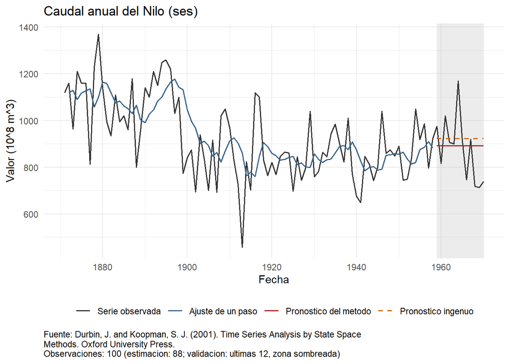

```r
g_final <- grafico_pronostico(datos, n_est, ajuste$yhat, pron, "Caudal anual del Nilo (ses)", ingenuo = pron_ing)
ggsave("figs/e3-final.png", g_final, width = 8, height = 4.5)
g_final
```

Aunque el pronóstico ingenuo pueda parecer visualmente más cercano a la trayectoria de los datos de validación, las evaluaciones y métricas previas confirman que el método de suavizamiento exponencial simple comprende mejor la dinámica de la serie. En la gráfica se observa cómo el método asimiló de forma progresiva el cambio de nivel histórico ocurrido a finales del siglo XIX, logrando estabilizar la estimación del caudal promedio de manera sólida para las proyecciones futuras.

**Conclusión:** Se ajustó un modelo de Suavizamiento Exponencial Simple (SES) con un parámetro de suavizado óptimo $\alpha=0.24$, utilizando 88 datos de entrenamiento y 12 de validación. En comparación con el método ingenuo, que registró un MSE de 19 685, un MAE de 111 y un MAPE de 13.5%, el SES redujo las cifras a un MSE de 17 864, un MAE de 107 y un MAPE de 12.6%, con un MASE menor a 1. La validación de errores evidenció ausencia de sesgo (p=0.483), ausencia de autocorrelación (p=0.653 en Ljung-Box y Durbin-Watson de 1.6935) y normalidad en los residuos (p=0.848 en Jarque-Bera).

**Recomendación:** Este cálculo le sirve a los encargados de gestionar el agua del río o a los agricultores de la zona para calcular cuánta agua habrá disponible tras cambios importantes en el entorno (como la construcción de una presa). Es seguro utilizarlo para hacer planes desde 1 hasta 12 años hacia adelante. Su principal límite es que no adivina los años con lluvias o sequías extremas, equivocándose en promedio en un 12.6% del agua real del río.

# 4 Ejemplo 4: Doble Media Móvil

La serie registra el precio relativo de la gasolina entre enero de 1969 y diciembre de 1984, correspondiente a la variable `PetrolPrice` del conjunto de datos `Seatbelts` en R. Cuenta con un total de 192 observaciones mensuales (frecuencia 12). Los datos provienen de las investigaciones de Harvey (1989), así como de Durbin y Koopman (2001) sobre modelos de series de tiempo.

**Mostrar/ocultar código**

```r
# 1. Descripción
fuente <- fuente_help("Seatbelts")
datos <- leer_serie(Seatbelts[, "PetrolPrice"], fuente, "precio de la gasolina")
n <- nrow(datos)
y <- datos$y

stopifnot(n == length(Seatbelts[, "PetrolPrice"]), all(y == as.numeric(Seatbelts[, "PetrolPrice"])))

df_desc <- data.frame(
  Propiedad = c("Nombre en R", "Fuente", "Unidad", "Frecuencia", "Rango Fechas", "Observaciones"),
  Detalle = c("Seatbelts[, 'PetrolPrice']", fuente, "precio de la gasolina",
              attr(datos, "frecuencia"),
              paste(format(min(datos$fecha)), "a", format(max(datos$fecha))),
              as.character(n))
)
formatear_tabla(df_desc, "1. DESCRIPCIÓN - Ejemplo 4")
```

1. DESCRIPCIÓN - Ejemplo 4

| Propiedad | Detalle |
| --- | --- |
| Nombre en R | Seatbelts[, 'PetrolPrice'] |
| Fuente | Harvey, A.C. (1989). Forecasting, Structural Time Series Models and the Kalman Filter. Cambridge University Press, pp. 519-523. Durbin, J. and Koopman, S. J. (2001). Time Series Analysis by State Spac… |
| Unidad | precio de la gasolina |
| Frecuencia | 12 |
| Rango Fechas | 1969-01-01 a 1984-12-01 |
| Observaciones | 192 |

## 4.1 Patrón de la Serie

**Gráficos**

**Mostrar/ocultar código**

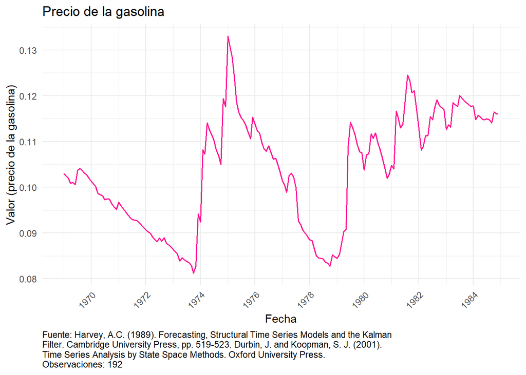

```r
# 2. Patrón de la Serie
g_serie <- graficar_serie(datos, "Precio de la gasolina")
ggsave("figs/e4-serie.png", g_serie, width = 8, height = 4.5)
g_serie
```

**Mostrar/ocultar código**

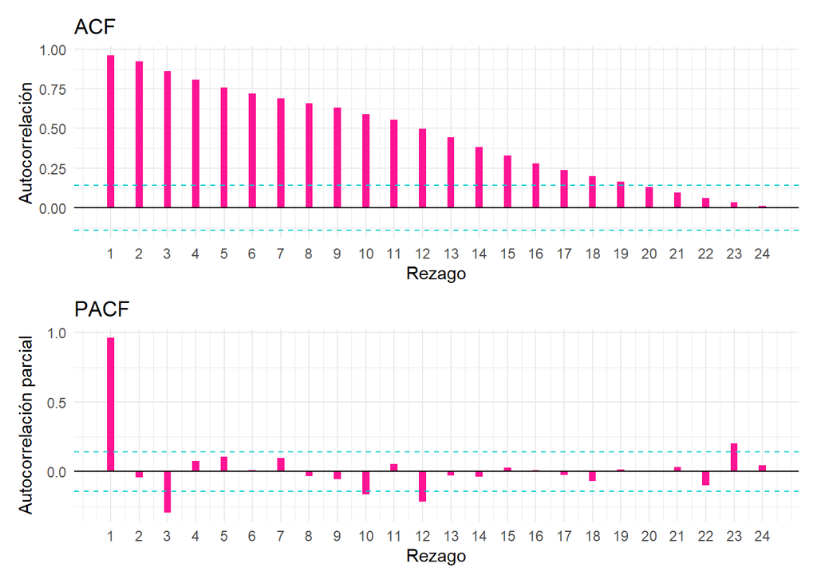

```r
g_corr <- correlograma(datos)
ggsave("figs/e4-correlograma.png", g_corr, width = 8, height = 6)
g_corr
```

La serie presenta múltiples cambios de nivel a lo largo del tiempo, lo que sugiere que no es estacionaria en media. Este comportamiento se confirma en el correlograma al observar un decaimiento lento hacia cero a medida que aumentan los rezagos. Aunque visualmente se aprecian ciertos patrones en la trayectoria de los datos, el correlograma no muestra la presencia de rezagos múltiples significativos.

**Contraste**

**Mostrar/ocultar código**

```r
m <- min(floor(n / 4), 24)
r <- acf_manual(y, m)
limite <- qnorm(0.975) / sqrt(n)

contraste <- data.frame(rezago = 1:m, rh = r, z = r * sqrt(n), fuera_de_banda = abs(r) > limite)

formatear_tabla(data.frame(banda = limite, r1 = r[1], rezagos_fuera = sum(contraste$fuera_de_banda), esperados_por_azar = 0.05 * m), "Resumen del Contraste")
```

Resumen del Contraste

| banda | r1 | rezagos_fuera | esperados_por_azar |
| --- | --- | --- | --- |
| 0.1414 | 0.9622 | 19 | 1.2 |

**Mostrar/ocultar código**

```r
formatear_tabla(contraste[contraste$fuera_de_banda, ], "Rezagos Fuera de Banda")
```

Rezagos Fuera de Banda

| rezago | rh | z | fuera_de_banda |
| --- | --- | --- | --- |
| 1 | 0.9622 | 13.3323 | TRUE |
| 2 | 0.9225 | 12.7830 | TRUE |
| 3 | 0.8624 | 11.9496 | TRUE |
| 4 | 0.8091 | 11.2116 | TRUE |
| 5 | 0.7601 | 10.5328 | TRUE |
| 6 | 0.7181 | 9.9508 | TRUE |
| 7 | 0.6877 | 9.5292 | TRUE |
| 8 | 0.6582 | 9.1209 | TRUE |
| 9 | 0.6308 | 8.7409 | TRUE |
| 10 | 0.5912 | 8.1922 | TRUE |
| 11 | 0.5546 | 7.6846 | TRUE |
| 12 | 0.4985 | 6.9070 | TRUE |
| 13 | 0.4447 | 6.1623 | TRUE |
| 14 | 0.3829 | 5.3052 | TRUE |
| 15 | 0.3294 | 4.5640 | TRUE |
| 16 | 0.2812 | 3.8971 | TRUE |
| 17 | 0.2385 | 3.3049 | TRUE |
| 18 | 0.1995 | 2.7643 | TRUE |
| 19 | 0.1631 | 2.2598 | TRUE |

Al evaluar los primeros 24 rezagos en el correlograma, se observa que 19 de ellos se encuentran fuera de las bandas de significancia. Este comportamiento refleja la presencia de una fuerte autocorrelación en la serie, confirmando la alta dependencia entre las observaciones a lo largo de los meses anteriores.

**Ljung Box**

**Mostrar/ocultar código**

```r
lb_serie <- ljung_box(r, n, m, 0)
mostrar_prueba_html("Ljung-Box sobre la serie (p = 0)",
               "todas las autocorrelaciones hasta m son cero", "alguna es distinta de cero",
               paste0("chi2 con ", lb_serie$gl, " g.l."), lb_serie)
```

Prueba de Hipótesis: Ljung-Box sobre la serie (p = 0)

| H0 | todas las autocorrelaciones hasta m son cero |
| --- | --- |
| H1 | alguna es distinta de cero |
| Estadístico | 1436.7 |
| Distribución | chi2 con 24 g.l. |
| Valor Crítico 5% | 36.415 |
| Valor p | 7.06e-289 |
| Decisión | se rechaza H0 al 5% |

**Mostrar/ocultar código**

```r
verificar_ljung_box(y, m)
```

```
Ljung-Box (m = 24 , p = 0 )
   Q propio: 1436.705311 | Q de R: 1436.705311
```

el valor p es menor que cualquier $\alpha$, por tanto se rechaza H0, es decir existe autocorrelacion, algo que se confirmaba con los contrastes anteriores

**Partición**

**Mostrar/ocultar código**

```r
h <- min(12, floor(0.2 * n))
n_est <- n - h
y_est <- y[1:n_est]
y_val <- y[(n_est + 1):n]

formatear_tabla(data.frame(h = h, estimacion = n_est, validacion = h), "Partición de la Serie")
```

Partición de la Serie

| h | estimacion | validacion |
| --- | --- | --- |
| 12 | 180 | 12 |

La serie se dividió en un conjunto de entrenamiento con 180 observaciones para la estimación del modelo y un conjunto de validación con los 12 datos restantes para la evaluación de los pronósticos.

## 4.2 Método

Se optó por el método de Doble Media Móvil debido a que la serie exhibe una tendencia dinámica con variaciones continuas a lo largo del tiempo. A diferencia de la media móvil simple, este método permite corregir el rezago estructural ante la presencia de tendencia, adaptándose con mayor rapidez a las fluctuaciones y cambios de dirección del precio.

**Optimización**

**Mostrar/ocultar código**

```r
# 3. Ajuste (dmm)
opt <- optimizar(y_est, "dmm")
formatear_tabla(cbind(opt$optimo, en_borde = opt$en_borde), "4. AJUSTE (dmm) - Optimización")
```

4. AJUSTE (dmm) - Optimización

| k | mse | en_borde |
| --- | --- | --- |
| 2 | 0 | TRUE |

**Mostrar/ocultar código**

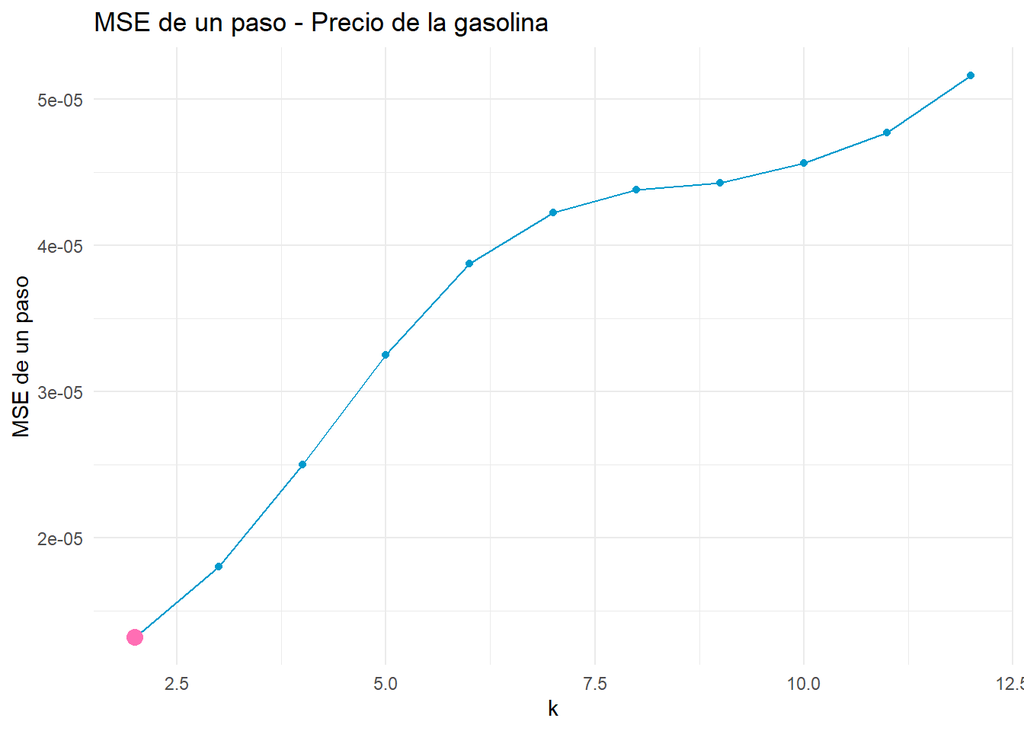

```r
g_opt <- grafico_mse(opt, "MSE de un paso - Precio de la gasolina")
ggsave("figs/e4-optimizacion.png", g_opt, width = 7, height = 5)
g_opt
```

**Mostrar/ocultar código**

```r
interpretar_borde(opt)
```

```
  El optimo cae en el borde inferior de k: una ventana muy corta.
```

El proceso de optimización determinó un valor óptimo de k=2, por lo que los promedios se calcularán considerando únicamente dos periodos. No obstante, al analizar el error cuadrático medio (MSE), se observa que este se ubica en el límite inferior del rango de búsqueda, lo que indica que el algoritmo alcanzó la restricción de optimización impuesta para dicho parámetro. En el gráfico se ve que el error sube de forma continua a medida que la ventana crece, sin ningún mínimo interior: mientras más corto es el período usado para promediar, menor es el error, y el mejor resultado queda justo en el extremo permitido. Esto significa que el precio de la gasolina cambia tan rápido de un mes a otro que conviene seguirlo muy de cerca, casi con el dato más reciente

**Medidas**

**Mostrar/ocultar código**

```r
ajuste <- ajustar_dmm(y_est, opt$optimo$k)
p <- 1

pron <- ajuste$pronosticar(h)
pron_ing <- ingenuo(y_est, h)

tabla <- rbind(
  data.frame(caso = "Método, un paso (estimación)", medidas(y_est, ajuste$yhat, y_est)),
  data.frame(caso = "Método, h pasos (validación)", medidas(y_val, pron, y_est)),
  data.frame(caso = "Ingenuo, h pasos (validación)", medidas(y_val, pron_ing, y_est)))
formatear_tabla(tabla, "Medidas y Comparación")
```

Medidas y Comparación

| caso | MSE | MAD | MAPE | MASE | n |
| --- | --- | --- | --- | --- | --- |
| Método, un paso (estimación) | 0 | 0.0022 | 2.0121 | 1.1781 | 177 |
| Método, h pasos (validación) | 0 | 0.0012 | 1.0247 | 0.6433 | 12 |
| Ingenuo, h pasos (validación) | 0 | 0.0022 | 1.9537 | 1.2192 | 12 |

El método de Doble Media Móvil obtiene un mejor desempeño que el método ingenuo en todas las métricas evaluadas. En el caso del MSE, el método registra un valor aproximadamente la mitad que el del ingenuo, lo que indica que en promedio comete menos errores. Asimismo, la desviación absoluta media (MAD) es de 0.001, lo que muestra que en promedio se equivoca en menos de una unidad. En términos porcentuales (MAPE), el método escogido se aleja en promedio un 1% de los valores reales, mientras que el ingenuo lo hace en casi un 2%. Finalmente, el MASE es menor que 1, por tanto se ratifica que es un mejor método que el ingenuo.

**Validación Errores**

**Mostrar/ocultar código**

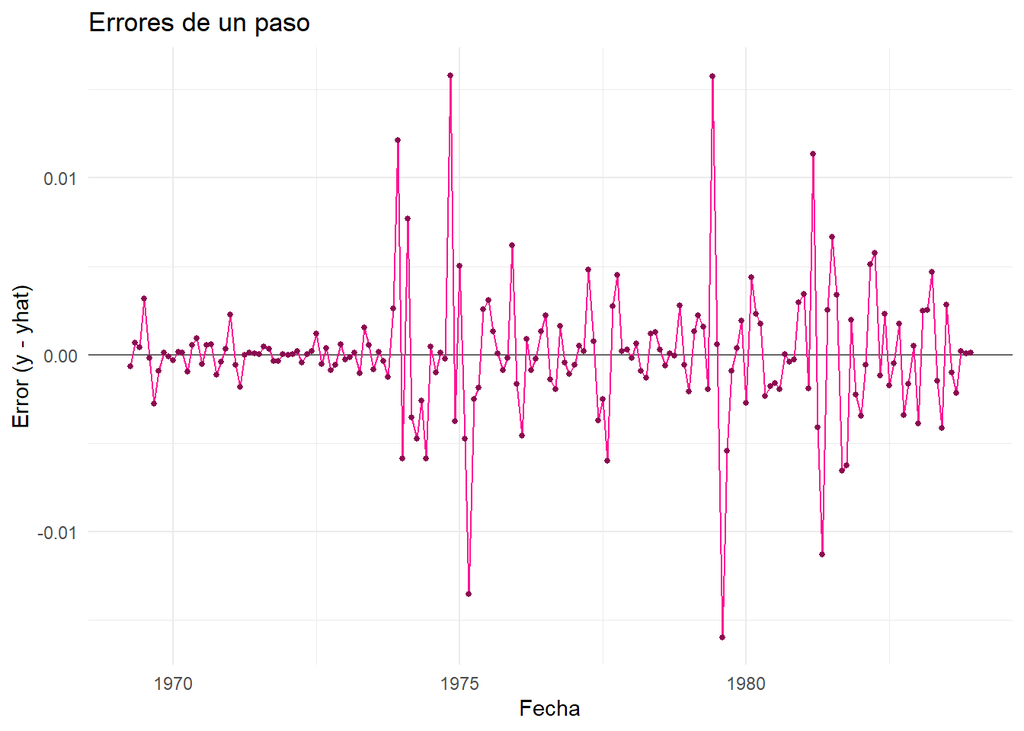

```r
# 4. Errores de un paso
errores <- y_est - ajuste$yhat
ve <- validar_errores(errores, p = p, fechas = datos$fecha[1:n_est])

ggsave("figs/e4-errores.png", ve$grafico_errores, width = 8, height = 3.5)
ggsave("figs/e4-correlograma-errores.png", ve$correlograma, width = 8, height = 6)

ve$grafico_errores
```

**Mostrar/ocultar código**

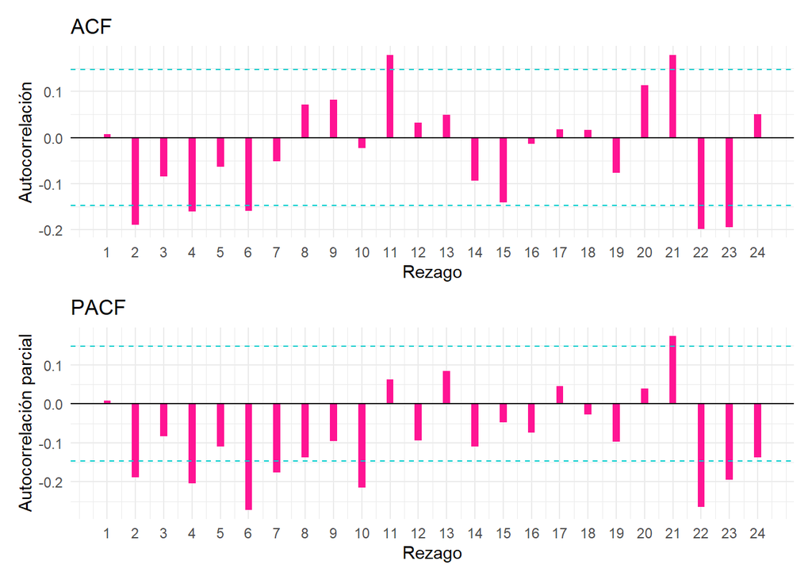

```r
ve$correlograma
```

Los errores oscilan de manera aleatoria alrededor de cero, aunque se evidencian algunos valores muy alejados. Por su parte, en el correlograma aún se aprecian algunos rezagos que sobrepasan las bandas de significancia, lo que sugiere la persistencia de cierta autocorrelación en los residuos

**Pruebas**

**Mostrar/ocultar código**

```r
mostrar_prueba_html("t de media cero", "E[e] = 0", "E[e] distinto de 0", paste0("t con ", ve$prueba_t$gl, " g.l."), ve$prueba_t)
```

Prueba de Hipótesis: t de media cero

| H0 | E[e] = 0 |
| --- | --- |
| H1 | E[e] distinto de 0 |
| Estadístico | 0.0023485 |
| Distribución | t con 179 g.l. |
| Valor Crítico 5% | 1.9733 |
| Valor p | 0.998 |
| Decisión | no se rechaza H0 al 5% |

**Mostrar/ocultar código**

```r
mostrar_prueba_html("Ljung-Box sobre los errores", "no hay autocorrelación hasta m", "hay autocorrelación", paste0("chi2 con ", ve$ljung_box$gl, " g.l. (m - p)"), ve$ljung_box)
```

Prueba de Hipótesis: Ljung-Box sobre los errores

| H0 | no hay autocorrelación hasta m |
| --- | --- |
| H1 | hay autocorrelación |
| Estadístico | 60.655 |
| Distribución | chi2 con 23 g.l. (m - p) |
| Valor Crítico 5% | 35.172 |
| Valor p | 3.07e-05 |
| Decisión | se rechaza H0 al 5% |

**Mostrar/ocultar código**

```r
mostrar_prueba_html("Jarque-Bera", "los errores son normales", "los errores no son normales", "chi2 con 2 g.l. (asintótica)", ve$jarque_bera, nota = if (ve$n < 20) paste("solo hay", ve$n, "errores (< 20): la decisión es poco fiable"))
```

Prueba de Hipótesis: Jarque-Bera

| H0 | los errores son normales |
| --- | --- |
| H1 | los errores no son normales |
| Estadístico | 342.93 |
| Distribución | chi2 con 2 g.l. (asintótica) |
| Valor Crítico 5% | 5.9915 |
| Valor p | 3.41e-75 |
| Decisión | se rechaza H0 al 5% |

**Mostrar/ocultar código**

```r
mostrar_prueba_html("Durbin-Watson", "no hay autocorrelación de primer orden", "hay autocorrelación de primer orden", "d entre 0 y 4", ve$durbin_watson)
```

Prueba de Hipótesis: Durbin-Watson

| H0 | no hay autocorrelación de primer orden |
| --- | --- |
| H1 | hay autocorrelación de primer orden |
| Estadístico | 1.9844 |
| Distribución | d entre 0 y 4 |
| Valor Crítico 5% | no aplica |
| Valor p | no aplica |
| Decisión | se compara con las cotas dL y dU de la tabla |

**t de media cero:** Al obtener un valor p de 0.998, no se rechaza la hipótesis nula, lo que confirma que los errores tienen media cero y no existe un sesgo en las estimaciones del método.

**Ljung-Box:** El valor p es menor que cualquier nivel de significancia , por lo que se rechaza la hipótesis nula. Esto indica la presencia de autocorrelación en los errores, confirmando que no se comportan como ruido blanco, tal como se apreciaba en el correlograma.

**Jarque-Bera:** El valor p es inferior a cualquier nivel de significancia , por lo que se rechaza la hipótesis nula, concluyendo que los errores no siguen una distribución normal.

**Durbin-Watson:** Con un valor de 1.9844 (muy cercano a 2), se sugiere la ausencia de autocorrelación lineal de primer orden entre periodos consecutivos.

### 4.2.1 Gráfico Final

**Mostrar/ocultar código**

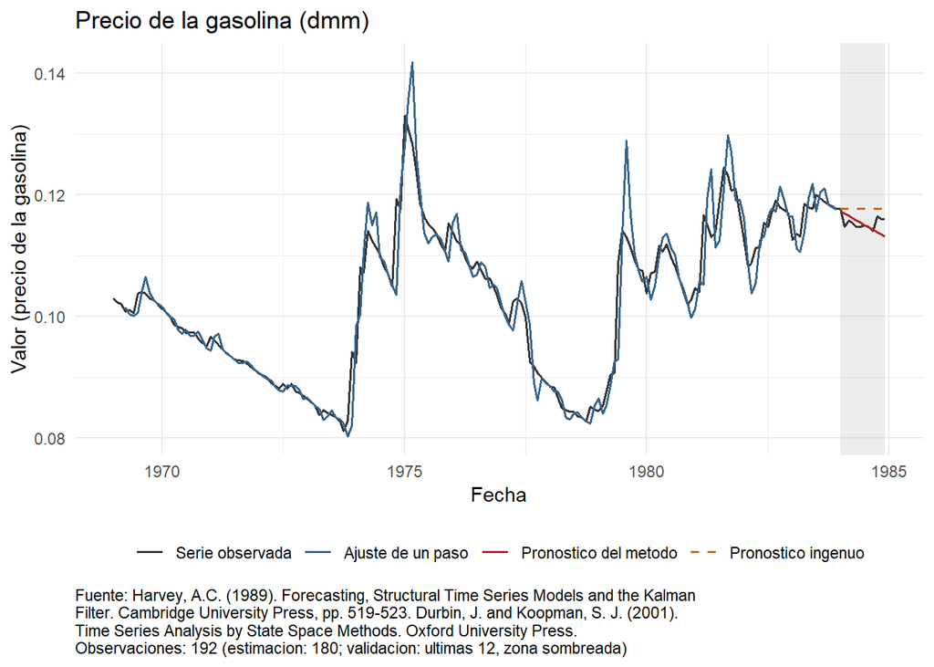

```r
g_final <- grafico_pronostico(datos, n_est, ajuste$yhat, pron, "Precio de la gasolina (dmm)", ingenuo = pron_ing)
ggsave("figs/e4-final.png", g_final, width = 8, height = 4.5)
g_final
```

En la figura se evidencia que el método de Doble Media Móvil se adapta de mejor manera a la estructura del precio de la gasolina. Durante la etapa de estimación, el ajuste a un paso capta con precisión los continuos cambios de nivel de la serie. Asimismo, en el periodo de validación, las proyecciones se aproximan en mayor medida a los datos reales en comparación con el pronóstico ingenuo, ya que este último no logra considerar la dinámica de la tendencia presente en la serie.

Al revisar la estructura de los errores, se evidencia la presencia de patrones remanentes, lo que confirma que no se comportan como ruido blanco. Esta situación se explica por el uso de una ventana tan corta (k=2); si bien un valor pequeño de k permite seguir de muy cerca la trayectoria y los cambios rápidos de la serie, pero a costa de dejar información y dinámicas sin explicar en los residuos

**Conclusión:** Se ajustó un modelo de Doble Media Móvil con un parámetro de ventana óptimo en el límite inferior de k=2, aprovechando 180 datos mensuales de entrenamiento y 12 de validación. Frente al método ingenuo, que presentó un MAPE cercano al 2%, el modelo óptimo redujo las cifras a la mitad con un MAD de 0.001, un MAPE del 1% y un MASE menor a 1. En la validación de errores, el modelo mostró ausencia de sesgo (p=0.998) y ausencia de autocorrelación de primer orden (DW=1.9844), pero no superó Ljung-Box (p<0.05) ni Jarque-Bera (p<0.05), manteniendo residuos autocorrelacionados.

**Recomendaciones:** La fórmula le resulta útil a los dueños de gasolineras o empresas de transporte que compran combustible mes a mes y necesitan reaccionar rápido si el precio empieza a subir o bajar. Solo es recomendable usarlo para proyectar a muy corto plazo, entre 1 y 3 meses. Su límite está en que, al reaccionar tan rápido usando solo la información de los últimos 2 meses, se le escapan detalles más complejos del mercado, manteniendo una falla del 1% en sus pronósticos.

# 5 Ejemplo 5: Tendencia Lineal

La serie registra la población residente en Australia expresada en miles de personas, correspondiente al conjunto de datos `austres` en R. Cuenta con un total de 89 observaciones trimestrales (frecuencia 4), abarcando desde abril de 1971 hasta abril de 1993. Los datos provienen de la publicación de Brockwell y Davis (1996) sobre análisis de series de tiempo.

**Mostrar/ocultar código**

```r
# 1. Descripción
fuente <- fuente_help("austres")
datos <- leer_serie(austres, fuente, "miles de residentes")
n <- nrow(datos)
y <- datos$y

stopifnot(n == length(austres), all(y == as.numeric(austres)))

df_desc <- data.frame(
  Propiedad = c("Nombre en R", "Fuente", "Unidad", "Frecuencia", "Rango Fechas", "Observaciones"),
  Detalle = c("austres", fuente, "miles de residentes",
              attr(datos, "frecuencia"),
              paste(format(min(datos$fecha)), "a", format(max(datos$fecha))),
              as.character(n))
)
formatear_tabla(df_desc, "1. DESCRIPCIÓN - Ejemplo 5")
```

1. DESCRIPCIÓN - Ejemplo 5

| Propiedad | Detalle |
| --- | --- |
| Nombre en R | austres |
| Fuente | P. J. Brockwell and R. A. Davis (1996) Introduction to Time Series and Forecasting. Springer |
| Unidad | miles de residentes |
| Frecuencia | 4 |
| Rango Fechas | 1971-04-01 a 1993-04-01 |
| Observaciones | 89 |

## 5.1 Patrón de la Serie

**Gráficos**

**Mostrar/ocultar código**

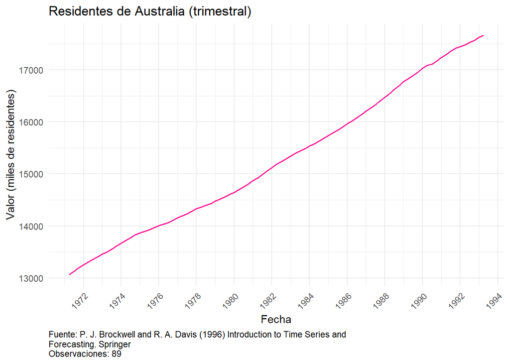

```r
# 2. Patrón de la Serie
g_serie <- graficar_serie(datos, "Residentes de Australia (trimestral)")
ggsave("figs/e5-serie.png", g_serie, width = 8, height = 4.5)
g_serie
```

**Mostrar/ocultar código**

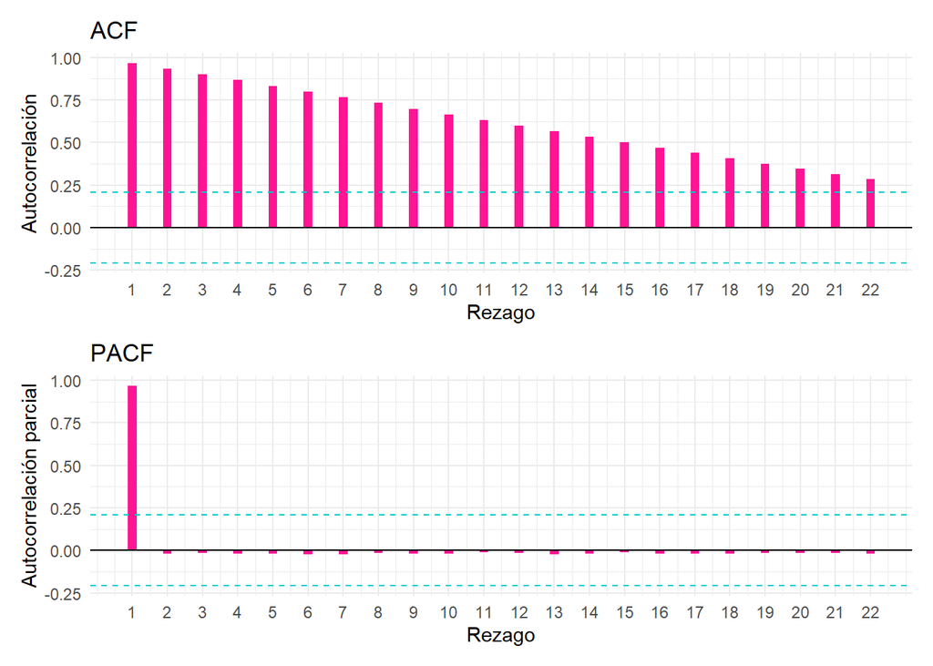

```r
g_corr <- correlograma(datos)
ggsave("figs/e5-correlograma.png", g_corr, width = 8, height = 6)
g_corr
```

La serie exhibe una clara tendencia creciente con una trayectoria prácticamente rectilínea a lo largo del tiempo. Este comportamiento se confirma en el correlograma (ACF) mediante un decrecimiento lento hacia cero a medida que aumentan los rezagos. Asimismo, en la función de autocorrelación parcial (PACF), el primer rezago alcanza un valor cercano a 1, lo que señala la falta de estacionariedad en media de la serie.

**Contraste**

**Mostrar/ocultar código**

```r
m <- min(floor(n / 4), 24)
r <- acf_manual(y, m)
limite <- qnorm(0.975) / sqrt(n)

contraste <- data.frame(rezago = 1:m, rh = r, z = r * sqrt(n), fuera_de_banda = abs(r) > limite)

formatear_tabla(data.frame(banda = limite, r1 = r[1], rezagos_fuera = sum(contraste$fuera_de_banda), esperados_por_azar = 0.05 * m), "Resumen del Contraste")
```

Resumen del Contraste

| banda | r1 | rezagos_fuera | esperados_por_azar |
| --- | --- | --- | --- |
| 0.2078 | 0.9666 | 22 | 1.1 |

**Mostrar/ocultar código**

```r
formatear_tabla(contraste[contraste$fuera_de_banda, ], "Rezagos Fuera de Banda")
```

Rezagos Fuera de Banda

| rezago | rh | z | fuera_de_banda |
| --- | --- | --- | --- |
| 1 | 0.9666 | 9.1188 | TRUE |
| 2 | 0.9330 | 8.8023 | TRUE |
| 3 | 0.8998 | 8.4886 | TRUE |
| 4 | 0.8665 | 8.1742 | TRUE |
| 5 | 0.8330 | 7.8584 | TRUE |
| 6 | 0.7993 | 7.5405 | TRUE |
| 7 | 0.7654 | 7.2209 | TRUE |
| 8 | 0.7317 | 6.9030 | TRUE |
| 9 | 0.6982 | 6.5866 | TRUE |
| 10 | 0.6647 | 6.2709 | TRUE |
| 11 | 0.6318 | 5.9604 | TRUE |
| 12 | 0.5993 | 5.6534 | TRUE |
| 13 | 0.5665 | 5.3439 | TRUE |
| 14 | 0.5339 | 5.0371 | TRUE |
| 15 | 0.5020 | 4.7360 | TRUE |
| 16 | 0.4702 | 4.4363 | TRUE |
| 17 | 0.4385 | 4.1372 | TRUE |
| 18 | 0.4069 | 3.8390 | TRUE |
| 19 | 0.3759 | 3.5462 | TRUE |
| 20 | 0.3453 | 3.2578 | TRUE |
| 21 | 0.3152 | 2.9738 | TRUE |
| 22 | 0.2853 | 2.6917 | TRUE |

Al evaluar los primeros 22 rezagos en el correlograma, se observa que la totalidad de ellos (22) se encuentran por fuera de las bandas de significancia. Este comportamiento refleja la presencia de una autocorrelación extremadamente fuerte en la serie, confirmando una elevada dependencia lineal entre las observaciones a lo largo de los trimestres evaluados.

**Ljung Box**

**Mostrar/ocultar código**

```r
lb_serie <- ljung_box(r, n, m, 0)
mostrar_prueba_html("Ljung-Box sobre la serie (p = 0)",
               "todas las autocorrelaciones hasta m son cero", "alguna es distinta de cero",
               paste0("chi2 con ", lb_serie$gl, " g.l."), lb_serie)
```

Prueba de Hipótesis: Ljung-Box sobre la serie (p = 0)

| H0 | todas las autocorrelaciones hasta m son cero |
| --- | --- |
| H1 | alguna es distinta de cero |
| Estadístico | 938.95 |
| Distribución | chi2 con 22 g.l. |
| Valor Crítico 5% | 33.924 |
| Valor p | 1.88e-184 |
| Decisión | se rechaza H0 al 5% |

**Mostrar/ocultar código**

```r
verificar_ljung_box(y, m)
```

```
Ljung-Box (m = 22 , p = 0 )
   Q propio: 938.9522206 | Q de R: 938.9522206
```

El valor p es menor que cualquier nivel de significancia $\alpha$, por lo que se rechaza la hipótesis nula. Esto proporciona evidencia suficiente para sugerir la presencia de autocorrelación en la serie, confirmando lo observado tanto en el conteo de rezagos fuera de las bandas como en el comportamiento del correlograma.

**Partición**

**Mostrar/ocultar código**

```r
h <- min(12, floor(0.2 * n))
n_est <- n - h
y_est <- y[1:n_est]
y_val <- y[(n_est + 1):n]

formatear_tabla(data.frame(h = h, estimacion = n_est, validacion = h), "Partición de la Serie")
```

Partición de la Serie

| h | estimacion | validacion |
| --- | --- | --- |
| 12 | 77 | 12 |

La serie se dividió en un conjunto de entrenamiento de 77 observaciones trimestrales para la estimación del modelo y un conjunto de validación de 12 datos para evaluar la capacidad predictiva de las estimaciones.

## 5.2 Método

Tal como se evidenciaba en el gráfico preliminar de la serie, los datos muestran una trayectoria de crecimiento a lo largo del tiempo. Por lo tanto, se decidió utilizar un modelo de Tendencia Lineal para capturar de manera adecuada esta dinámica

**Medidas**

**Mostrar/ocultar código**

```r
# 3. Ajuste (lineal)
ajuste <- ajustar_tendencia(y_est, "lineal")
p <- 2

pron <- ajuste$pronosticar(h)
pron_ing <- ingenuo(y_est, h)

tabla <- rbind(
  data.frame(caso = "Método, un paso (estimación)", medidas(y_est, ajuste$yhat, y_est)),
  data.frame(caso = "Método, h pasos (validación)", medidas(y_val, pron, y_est)),
  data.frame(caso = "Ingenuo, h pasos (validación)", medidas(y_val, pron_ing, y_est)))
formatear_tabla(tabla, "Medidas y Comparación")
```

Medidas y Comparación

| caso | MSE | MAD | MAPE | MASE | n |
| --- | --- | --- | --- | --- | --- |
| Método, un paso (estimación) | 8865.367 | 82.0932 | 0.5480 | 1.5527 | 77 |
| Método, h pasos (validación) | 44430.965 | 210.0804 | 1.2071 | 3.9735 | 12 |
| Ingenuo, h pasos (validación) | 133004.791 | 322.0417 | 1.8405 | 6.0912 | 12 |

La evaluación de los errores confirma que el método de Tendencia Lineal presenta un mejor desempeño que el pronóstico ingenuo, al registrar valores inferiores en todas las medidas consideradas. En el caso del MSE, el modelo obtiene un valor de 44 431, resultando ser más de dos veces menor que el del ingenuo, lo que indica que en promedio comete menos errores. Asimismo, la desviación absoluta media (MAD) señala que el modelo se equivoca en promedio en 210 unidades frente a las 322 unidades del método ingenuo. En términos porcentuales (MAPE), las estimaciones se alejan en promedio apenas un 1.2% de la realidad. Finalmente, el valor del MASE resulta ser menor que el del pronóstico de referencia, ratificando a la Tendencia Lineal como una mejor alternativa de modelación.

**Validación Errores**

**Mostrar/ocultar código**

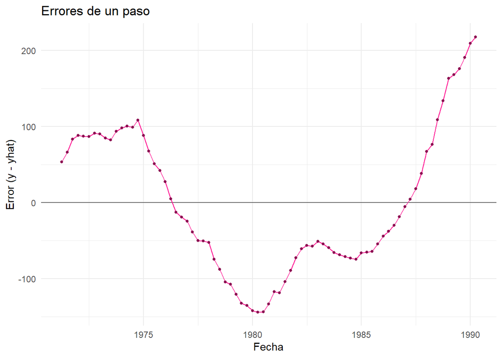

```r
# 4. Errores de un paso
errores <- y_est - ajuste$yhat
ve <- validar_errores(errores, p = p, fechas = datos$fecha[1:n_est])

ggsave("figs/e5-errores.png", ve$grafico_errores, width = 8, height = 3.5)
ggsave("figs/e5-correlograma-errores.png", ve$correlograma, width = 8, height = 6)

ve$grafico_errores
```

**Mostrar/ocultar código**

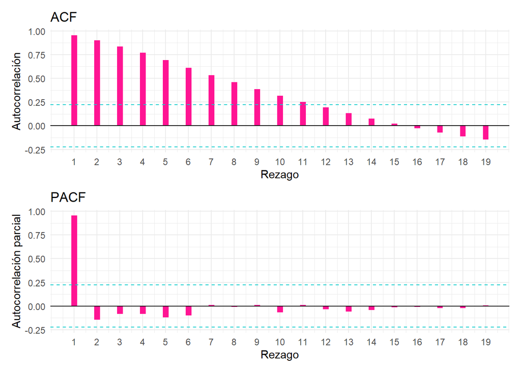

```r
ve$correlograma
```

Se observa que los errores no oscilan de manera aleatoria alrededor de cero, evidenciando patrones definidos en su comportamiento a lo largo del tiempo. Por su parte, en el correlograma persisten rezagos por fuera de las bandas de significancia, lo que sugiere que el modelo de tendencia lineal no logró capturar toda la información de la serie y, por tanto, los residuos no se comportan como ruido blanco.

**Pruebas**

**Mostrar/ocultar código**

```r
mostrar_prueba_html("t de media cero", "E[e] = 0", "E[e] distinto de 0", paste0("t con ", ve$prueba_t$gl, " g.l."), ve$prueba_t)
```

Prueba de Hipótesis: t de media cero

| H0 | E[e] = 0 |
| --- | --- |
| H1 | E[e] distinto de 0 |
| Estadístico | -2.6684e-13 |
| Distribución | t con 76 g.l. |
| Valor Crítico 5% | 1.9917 |
| Valor p | 1 |
| Decisión | no se rechaza H0 al 5% |

**Mostrar/ocultar código**

```r
mostrar_prueba_html("Ljung-Box sobre los errores", "no hay autocorrelación hasta m", "hay autocorrelación", paste0("chi2 con ", ve$ljung_box$gl, " g.l. (m - p)"), ve$ljung_box)
```

Prueba de Hipótesis: Ljung-Box sobre los errores

| H0 | no hay autocorrelación hasta m |
| --- | --- |
| H1 | hay autocorrelación |
| Estadístico | 399.47 |
| Distribución | chi2 con 17 g.l. (m - p) |
| Valor Crítico 5% | 27.587 |
| Valor p | 2.4e-74 |
| Decisión | se rechaza H0 al 5% |

**Mostrar/ocultar código**

```r
mostrar_prueba_html("Jarque-Bera", "los errores son normales", "los errores no son normales", "chi2 con 2 g.l. (asintótica)", ve$jarque_bera, nota = if (ve$n < 20) paste("solo hay", ve$n, "errores (< 20): la decisión es poco fiable"))
```

Prueba de Hipótesis: Jarque-Bera

| H0 | los errores son normales |
| --- | --- |
| H1 | los errores no son normales |
| Estadístico | 4.2355 |
| Distribución | chi2 con 2 g.l. (asintótica) |
| Valor Crítico 5% | 5.9915 |
| Valor p | 0.12 |
| Decisión | no se rechaza H0 al 5% |

**Mostrar/ocultar código**

```r
mostrar_prueba_html("Durbin-Watson", "no hay autocorrelación de primer orden", "hay autocorrelación de primer orden", "d entre 0 y 4", ve$durbin_watson)
```

Prueba de Hipótesis: Durbin-Watson

| H0 | no hay autocorrelación de primer orden |
| --- | --- |
| H1 | hay autocorrelación de primer orden |
| Estadístico | 0.017056 |
| Distribución | d entre 0 y 4 |
| Valor Crítico 5% | no aplica |
| Valor p | no aplica |
| Decisión | se compara con las cotas dL y dU de la tabla |

**t de media cero:** Al obtener un valor p aproximadamente de 1, no se rechaza la hipótesis nula, lo que indica que no hay evidencia suficiente para sugerir un sesgo promedio en las estimaciones; sin embargo, tal como se observó en la gráfica de residuos, persisten sesgos locales a lo largo del tiempo.

**Ljung-Box:** El valor p es menor que cualquier nivel de significancia , por lo que se rechaza la hipótesis nula. Esto proporciona evidencia suficiente de la presencia de autocorrelación en los errores, confirmando lo apreciado en el correlograma.

**Jarque-Bera:** Al registrar un valor p de 0.12, no se rechaza la hipótesis nula, concluyendo que no existe evidencia suficiente para dudar de la normalidad en la distribución de los errores.

**Durbin-Watson:** Con un valor de 0.017, al estar sumamente alejado de 2 (y muy cercano a 0), se confirma una fuerte autocorrelación positiva de primer orden, tal como lo señalaba el análisis de la función de autocorrelación parcial (PACF).

**Coeficientes y prueba t**

**Mostrar/ocultar código**

```r
# Coeficientes y prueba t con error estándar robusto (específico de tendencia)
coef <- ajuste$parametros$tabla
gl <- ajuste$parametros$n - nrow(coef)
formatear_tabla(coef, "Coeficientes de Regresión")
```

Coeficientes de Regresión

|  | estimacion | ee_ordinario | ee_robusto | t_ordinario | p_ordinario | t_robusto | p_robusto |
| --- | --- | --- | --- | --- | --- | --- | --- |
| beta0 | 12963.2882 | 21.9579 | 40.7328 | 590.3688 | 0 | 318.2520 | 0 |
| beta1 | 50.7075 | 0.4892 | 1.0491 | 103.6615 | 0 | 48.3365 | 0 |

**Mostrar/ocultar código**

```r
for (j in 1:nrow(coef)) {
  res <- list(estadistico = coef$t_robusto[j], valor_critico = qt(0.975, gl), valor_p = coef$p_robusto[j])
  mostrar_prueba_html(paste("t sobre", rownames(coef)[j], "(error estándar robusto)"),
                 paste(rownames(coef)[j], "= 0"), paste(rownames(coef)[j], "distinto de 0"),
                 paste0("t con ", gl, " g.l."), res)
}
```

La estimación de la pendiente ($\beta_{1} = 50.71$) indica que la población residente en Australia incrementa en promedio 50.71 miles de personas cada trimestre que transcurre. Con valores p prácticamente iguales a cero y estadísticos t elevados, se confirma la significancia estadística de este parámetro y de la tendencia creciente de la serie.

Al examinar los coeficientes, se observa una diferencia considerable entre los errores estándar ordinarios y los errores estándar robustos; los ordinarios son sensiblemente menores debido a que omiten la fuerte estructura de autocorrelación presente en los residuos, aparentando una precisión irreal. Esta autocorrelación en los errores ya había sido confirmada previamente mediante las gráficas y las pruebas formales de diagnóstico.

### 5.2.1 Gráfico Final

**Mostrar/ocultar código**

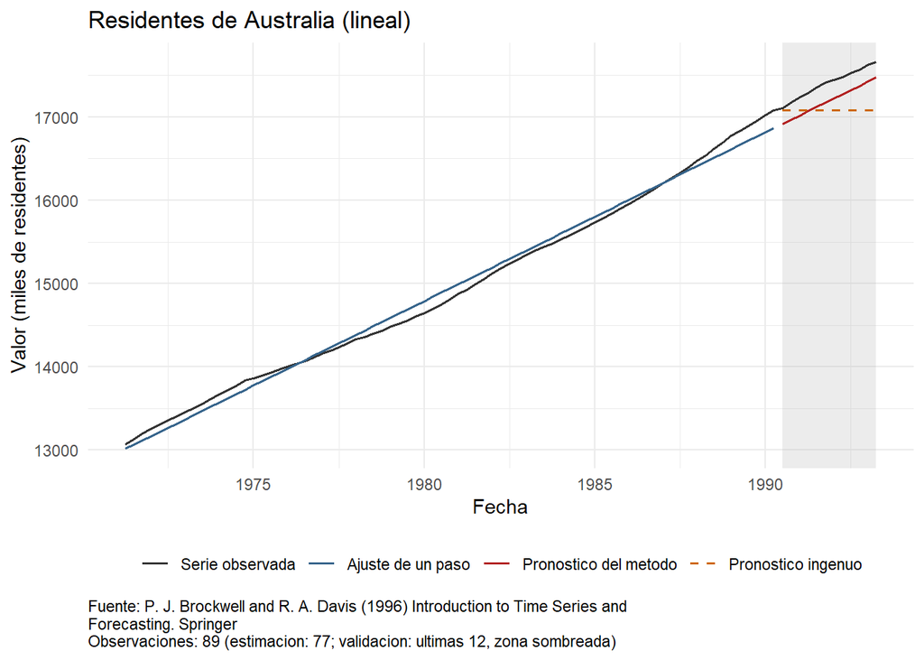

```r
g_final <- grafico_pronostico(datos, n_est, ajuste$yhat, pron, "Residentes de Australia (lineal)", ingenuo = pron_ing)
ggsave("figs/e5-final.png", g_final, width = 8, height = 4.5)
g_final
```

En la figura se aprecia claramente que el modelo de Tendencia Lineal ofrece un desempeño considerablemente superior al del método ingenuo. Este último proyecta una línea horizontal al asumir que los datos permanecerán constantes en el tiempo, ignorando por completo la marcada trayectoria creciente que presenta la población residente en Australia.

Por su parte, el modelo de tendencia lineal acompaña muy de cerca la trayectoria de la serie a lo largo del tiempo. Sin embargo, al mirar el pronóstico al final (la zona sombreada), la línea roja queda un poco por debajo de la línea negra real. Esto pasa porque en los últimos años la población empezó a crecer un poco más rápido de lo normal, y como este modelo usa un ritmo de crecimiento fijo, no alcanza a adaptarse a esa aceleración repentina.

**Recomendación:** Le sirve a los planificadores del gobierno que necesitan estimar cuánta gente vivirá en el país para construir escuelas o carreteras pensando que el país crece a un ritmo parejo. Es adecuado para hacer cálculos a mediano y largo plazo, abarcando hasta los 12 trimestres (3 años) analizados. Su límite es que asume una velocidad de crecimiento fija que no se adapta si la población de repente empieza a crecer más rápido, cometiendo una diferencia promedio de 210 mil personas.

# 6 Ejemplo 6: Tendencia Cuadrática

La serie registra las millas de pasajeros pagadas (revenue passenger miles) en la aviación comercial de Estados Unidos, correspondiente al conjunto de datos `airmiles` en R. Cuenta con un total de 24 observaciones anuales (frecuencia 1), abarcando desde 1937 hasta 1960. Los datos provienen del F.A.A. Statistical Handbook of Aviation.

**Mostrar/ocultar código**

```r
# 1. Descripción
fuente <- fuente_help("airmiles")
datos <- leer_serie(airmiles, fuente, "revenue passenger miles")
n <- nrow(datos)
y <- datos$y

stopifnot(n == length(airmiles), all(y == as.numeric(airmiles)))

df_desc <- data.frame(
  Propiedad = c("Nombre en R", "Fuente", "Unidad", "Frecuencia", "Rango Fechas", "Observaciones"),
  Detalle = c("airmiles", fuente, "revenue passenger miles",
              attr(datos, "frecuencia"),
              paste(format(min(datos$fecha)), "a", format(max(datos$fecha))),
              as.character(n))
)
formatear_tabla(df_desc, "1. DESCRIPCIÓN - Ejemplo 6")
```

1. DESCRIPCIÓN - Ejemplo 6

| Propiedad | Detalle |
| --- | --- |
| Nombre en R | airmiles |
| Fuente | F.A.A. Statistical Handbook of Aviation. |
| Unidad | revenue passenger miles |
| Frecuencia | 1 |
| Rango Fechas | 1937-01-01 a 1960-01-01 |
| Observaciones | 24 |

## 6.1 Patrón de la Serie

**Gráficos**

**Mostrar/ocultar código**

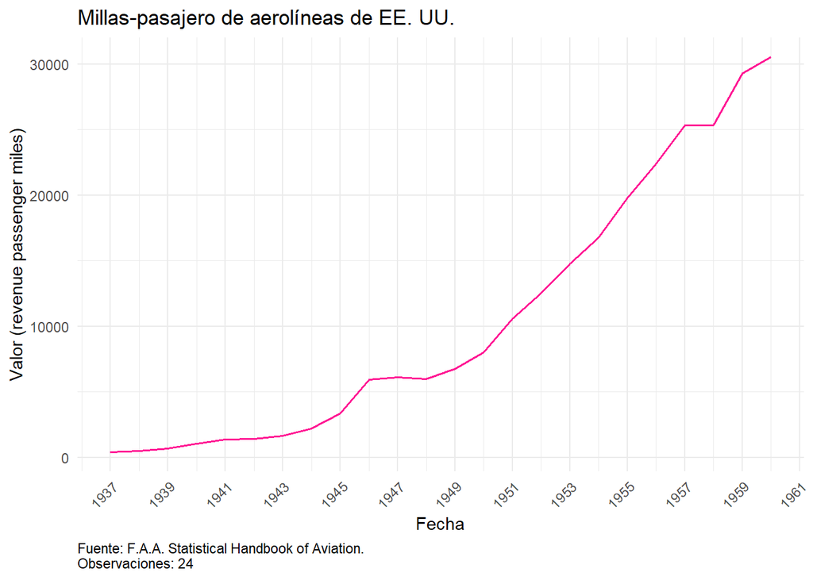

```r
# 2. Patrón de la Serie
g_serie <- graficar_serie(datos, "Millas-pasajero de aerolíneas de EE. UU.")
ggsave("figs/e6-serie.png", g_serie, width = 8, height = 4.5)
g_serie
```

**Mostrar/ocultar código**

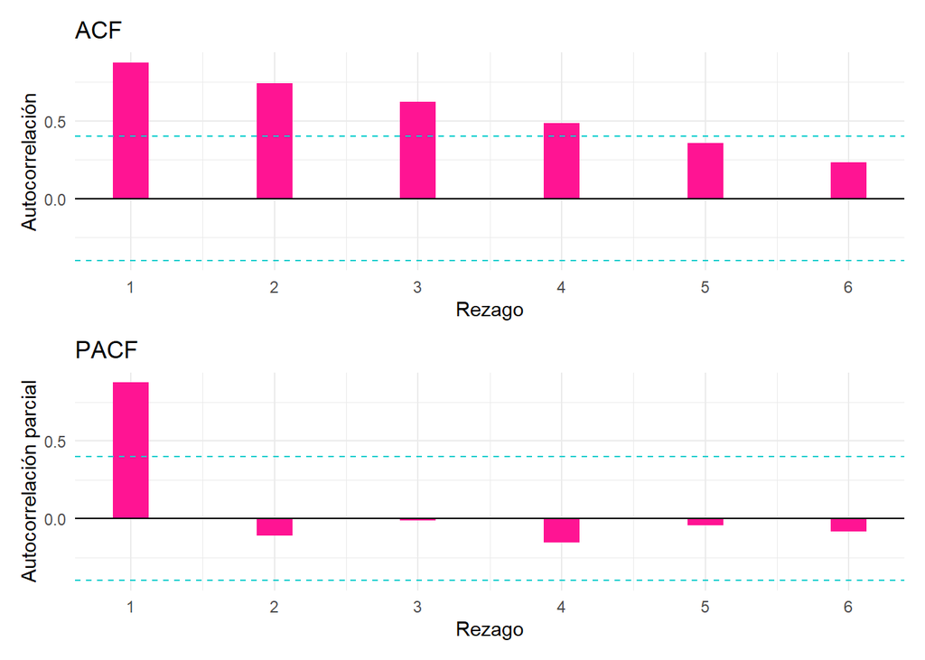

```r
g_corr <- correlograma(datos)
ggsave("figs/e6-correlograma.png", g_corr, width = 8, height = 6)
g_corr
```

La serie presenta una clara tendencia creciente que evidencia la falta de estacionariedad en media. A diferencia de la serie anterior, la trayectoria no muestra un comportamiento estrictamente rectilíneo, sino que sugiere una ligera curvatura a lo largo del tiempo. Por su parte, en el correlograma se ratifica la presencia de esta tendencia mediante el decrecimiento lento y progresivo de las autocorrelaciones a medida que aumentan los rezagos.

**Contraste**

**Mostrar/ocultar código**

```r
m <- min(floor(n / 4), 24)
r <- acf_manual(y, m)
limite <- qnorm(0.975) / sqrt(n)

contraste <- data.frame(rezago = 1:m, rh = r, z = r * sqrt(n), fuera_de_banda = abs(r) > limite)

formatear_tabla(data.frame(banda = limite, r1 = r[1], rezagos_fuera = sum(contraste$fuera_de_banda), esperados_por_azar = 0.05 * m), "Resumen del Contraste")
```

Resumen del Contraste

| banda | r1 | rezagos_fuera | esperados_por_azar |
| --- | --- | --- | --- |
| 0.4001 | 0.8761 | 4 | 0.3 |

**Mostrar/ocultar código**

```r
formatear_tabla(contraste[contraste$fuera_de_banda, ], "Rezagos Fuera de Banda")
```

Rezagos Fuera de Banda

| rezago | rh | z | fuera_de_banda |
| --- | --- | --- | --- |
| 1 | 0.8761 | 4.2920 | TRUE |
| 2 | 0.7422 | 3.6359 | TRUE |
| 3 | 0.6221 | 3.0476 | TRUE |
| 4 | 0.4849 | 2.3754 | TRUE |

Al evaluar los primeros 6 rezagos en el correlograma, se observa que la mayoría de ellos (4) se encuentran por fuera de las bandas de significancia. Este resultado confirma la presencia de autocorrelación en la serie y evidencia la dependencia lineal que existe entre los datos de periodos anuales consecutivos.

**Ljung Box**

**Mostrar/ocultar código**

```r
lb_serie <- ljung_box(r, n, m, 0)
mostrar_prueba_html("Ljung-Box sobre la serie (p = 0)",
               "todas las autocorrelaciones hasta m son cero", "alguna es distinta de cero",
               paste0("chi2 con ", lb_serie$gl, " g.l."), lb_serie)
```

Prueba de Hipótesis: Ljung-Box sobre la serie (p = 0)

| H0 | todas las autocorrelaciones hasta m son cero |
| --- | --- |
| H1 | alguna es distinta de cero |
| Estadístico | 61.307 |
| Distribución | chi2 con 6 g.l. |
| Valor Crítico 5% | 12.592 |
| Valor p | 2.44e-11 |
| Decisión | se rechaza H0 al 5% |

**Mostrar/ocultar código**

```r
verificar_ljung_box(y, m)
```

```
Ljung-Box (m = 6 , p = 0 )
   Q propio: 61.30673079 | Q de R: 61.30673079
```

El valor p es menor que cualquier nivel de significancia $\alpha$, por lo que se rechaza la hipótesis nula. Esto proporciona evidencia suficiente para sugerir la presencia de autocorrelación en la serie, confirmando lo observado tanto en el conteo de rezagos fuera de las bandas de significancia como en el comportamiento del correlograma.

**Partición**

**Mostrar/ocultar código**

```r
h <- min(12, floor(0.2 * n))
n_est <- n - h
y_est <- y[1:n_est]
y_val <- y[(n_est + 1):n]

formatear_tabla(data.frame(h = h, estimacion = n_est, validacion = h), "Partición de la Serie")
```

Partición de la Serie

| h | estimacion | validacion |
| --- | --- | --- |
| 4 | 20 | 4 |

La serie se dividió en un conjunto de entrenamiento compuesto por 20 observaciones anuales para la estimación del modelo y un conjunto de validación de 4 datos para evaluar el desempeño predictivo de las estimaciones.

## 6.2 Método

Dado que en el análisis gráfico preliminar se evidenció una clara tendencia creciente con una notable curvatura a lo largo del tiempo, se optó por emplear un modelo de Tendencia Cuadrática. Esta especificación permite capturar la aceleración en el crecimiento de la serie mejor que una recta tradicional.

**Medidas**

**Mostrar/ocultar código**

```r
tabla <- rbind(
  data.frame(caso = "Método, un paso (estimación)", medidas(y_est, ajuste$yhat, y_est)),
  data.frame(caso = "Método, h pasos (validación)", medidas(y_val, pron, y_est)),
  data.frame(caso = "Ingenuo, h pasos (validación)", medidas(y_val, pron_ing, y_est)))
formatear_tabla(tabla, "Medidas y Comparación")
```

Medidas y Comparación

[output not shown]

**Validación Errores**

**Mostrar/ocultar código**

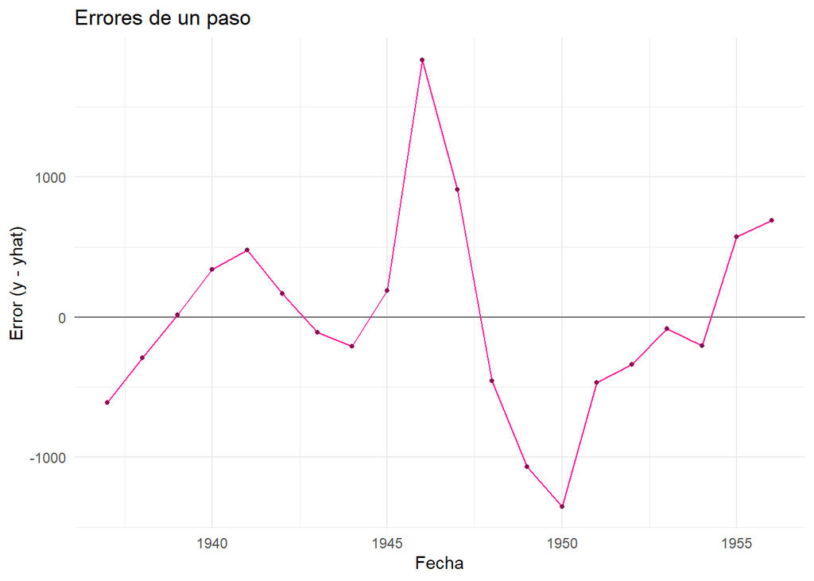

```r
# 4. Errores de un paso
errores <- y_est - ajuste$yhat
ve <- validar_errores(errores, p = p, fechas = datos$fecha[1:n_est])

ggsave("figs/e6-errores.png", ve$grafico_errores, width = 8, height = 3.5)
ggsave("figs/e6-correlograma-errores.png", ve$correlograma, width = 8, height = 6)

ve$grafico_errores
```

**Mostrar/ocultar código**

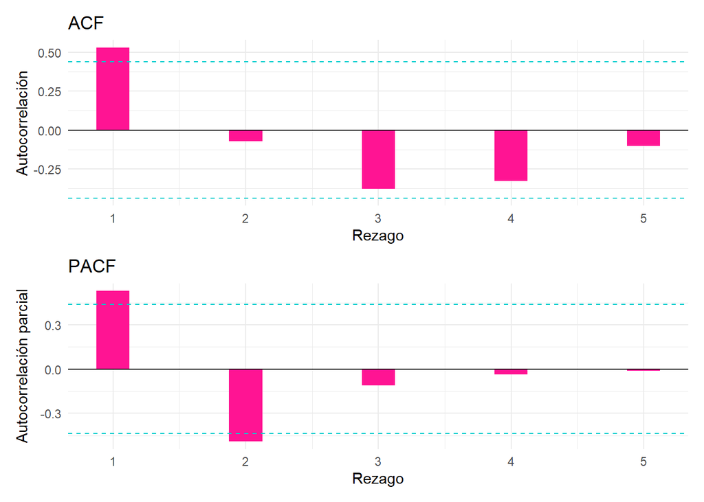

```r
ve$correlograma
```

Se observa que los errores no se distribuyen de manera aleatoria alrededor de cero, evidenciando fluctuaciones y patrones claros en su comportamiento a lo largo del tiempo. De igual forma, en el correlograma se aprecia que uno de los rezagos sobrepasa la banda de significancia, lo que sugiere la presencia de autocorrelación y permite sospechar que los residuos no se comportan como ruido blanco.

**Pruebas**

**Mostrar/ocultar código**

```r
mostrar_prueba_html("t de media cero", "E[e] = 0", "E[e] distinto de 0", paste0("t con ", ve$prueba_t$gl, " g.l."), ve$prueba_t)
```

Prueba de Hipótesis: t de media cero

| H0 | E[e] = 0 |
| --- | --- |
| H1 | E[e] distinto de 0 |
| Estadístico | -2.4862e-15 |
| Distribución | t con 19 g.l. |
| Valor Crítico 5% | 2.093 |
| Valor p | 1 |
| Decisión | no se rechaza H0 al 5% |

**Mostrar/ocultar código**

```r
mostrar_prueba_html("Ljung-Box sobre los errores", "no hay autocorrelación hasta m", "hay autocorrelación", paste0("chi2 con ", ve$ljung_box$gl, " g.l. (m - p)"), ve$ljung_box)
```

Prueba de Hipótesis: Ljung-Box sobre los errores

| H0 | no hay autocorrelación hasta m |
| --- | --- |
| H1 | hay autocorrelación |
| Estadístico | 13.633 |
| Distribución | chi2 con 2 g.l. (m - p) |
| Valor Crítico 5% | 5.9915 |
| Valor p | 0.0011 |
| Decisión | se rechaza H0 al 5% |

**Mostrar/ocultar código**

```r
mostrar_prueba_html("Jarque-Bera", "los errores son normales", "los errores no son normales", "chi2 con 2 g.l. (asintótica)", ve$jarque_bera, nota = if (ve$n < 20) paste("solo hay", ve$n, "errores (< 20): la decisión es poco fiable"))
```

Prueba de Hipótesis: Jarque-Bera

| H0 | los errores son normales |
| --- | --- |
| H1 | los errores no son normales |
| Estadístico | 1.5357 |
| Distribución | chi2 con 2 g.l. (asintótica) |
| Valor Crítico 5% | 5.9915 |
| Valor p | 0.464 |
| Decisión | no se rechaza H0 al 5% |

**Mostrar/ocultar código**

```r
mostrar_prueba_html("Durbin-Watson", "no hay autocorrelación de primer orden", "hay autocorrelación de primer orden", "d entre 0 y 4", ve$durbin_watson)
```

Prueba de Hipótesis: Durbin-Watson

| H0 | no hay autocorrelación de primer orden |
| --- | --- |
| H1 | hay autocorrelación de primer orden |
| Estadístico | 0.84885 |
| Distribución | d entre 0 y 4 |
| Valor Crítico 5% | no aplica |
| Valor p | no aplica |
| Decisión | se compara con las cotas dL y dU de la tabla |

**t de media cero:** Con un valor p aproximado de 1, no se rechaza la hipótesis nula, lo que indica que no hay evidencia suficiente para sugerir que existe un sesgo promedio; sin embargo, en la gráfica se evidencia que existen sesgos locales.

**Ljung-Box:** Con un valor p de 0.0011, se rechaza la hipótesis nula, lo que significa que hay evidencia suficiente para sugerir la presencia de autocorrelación en los errores, algo que ya se evidenciaba en el correlograma.

**Jarque-Bera:** Con un valor p de 0.464, no se rechaza la hipótesis nula; es decir, no existe evidencia suficiente para sugerir que los datos no siguen una distribución normal.

**Durbin-Watson:** Con un estadístico de 0.84885, al encontrarse considerablemente alejado de 2, se puede sospechar que existe autocorrelación de primer orden, un aspecto que también se observa en el correlograma.

**Coeficientes y prueba t**

**Mostrar/ocultar código**

```r
coef <- ajuste$parametros$tabla
gl <- ajuste$parametros$n - nrow(coef)
formatear_tabla(coef, "Coeficientes de Regresión Cuadrática")
```

Coeficientes de Regresión Cuadrática

|  | estimacion | ee_ordinario | ee_robusto | t_ordinario | p_ordinario | t_robusto | p_robusto |
| --- | --- | --- | --- | --- | --- | --- | --- |
| beta0 | 1420.1246 | 554.8976 | 517.1624 | 2.5593 | 0.0203 | 2.7460 | 0.0138 |
| beta1 | -473.9304 | 121.6976 | 149.3568 | -3.8943 | 0.0012 | -3.1731 | 0.0056 |
| beta2 | 74.3292 | 5.6291 | 6.8758 | 13.2045 | 0.0000 | 10.8103 | 0.0000 |

**Mostrar/ocultar código**

```r
for (j in 1:nrow(coef)) {
  res <- list(estadistico = coef$t_robusto[j], valor_critico = qt(0.975, gl), valor_p = coef$p_robusto[j])
  mostrar_prueba_html(paste("t sobre", rownames(coef)[j], "(error estándar robusto)"),
                 paste(rownames(coef)[j], "= 0"), paste(rownames(coef)[j], "distinto de 0"),
                 paste0("t con ", gl, " g.l."), res)
}
```

El coeficiente de la pendiente $\hat{\beta}_1$ es 473.93, es decir, por cada periodo que pasa va disminuyendo el valor inicial, mientras que $\hat{\beta}_2$ es 74.33, lo que indica que el crecimiento se acelera con el tiempo. Al mirar las pruebas individuales de los coeficientes, se confirma la significancia estadística de ambos, lo que demuestra que la presencia de la curvatura es significativa.